# Uber_data_Analysis

**🚗 Uber Trip EDA Pipeline**

**Introduction**

This project focuses on analyzing Uber trip data to gain insights into travel patterns, trip purposes, distances, durations, and temporal trends. By examining raw trip logs, we aim to uncover meaningful patterns that can help understand customer behavior, optimize route planning, and improve operational efficiency for ride-sharing services. The dataset contains information such as trip start and end times, origin and destination cities, mileage, purpose, and trip category (business or personal). Using Exploratory Data Analysis (EDA) and feature engineering, we clean, standardize, and enrich the data to prepare it for deeper insights and visualizations.

**Business Problem**

The business problem revolves around understanding operational and customer behavior for Uber or similar ride-sharing services. Questions of interest include:

1. Which trip types consume the most mileage?
2. Are certain trips unusually long or short?
3. When are trips most frequent during the day, week, or year?
4. How do different purposes (business, meetings, meals) affect travel patterns?

5.Which routes or city pairs are most traveled, and which are unusually long?

Addressing these questions can help optimize fleet deployment, plan resources efficiently, improve customer satisfaction, and reduce operational costs.

**Proposed Solution**

We solve this problem using a structured EDA pipeline and feature engineering approach:

1. **Data Cleaning:** Handle missing values, duplicates, and inconsistent city/purpose names.
2. **Feature Engineering: **Generate time-based features (hour, weekday, month), trip metrics (duration, miles per minute, trip type), and purpose grouping.
3. **Exploratory Analysis:** Visualize trips by time, purpose, and distance, detect outliers, and study origin-destination patterns.
4. **Deep Insights:** Identify peak trip types, mileage distribution, temporal trends, and high-impact routes.

This structured approach ensures that we transform raw trip logs into actionable insights, providing both statistical and visual evidence to support operational and strategic decisions.

**Why These Libraries Are Imported in This Project**

In this project, these four Python libraries play essential roles in data loading, cleaning, feature engineering, and Exploratory Data Analysis (EDA). Pandas is used as the primary data manipulation tool, allowing us to read the CSV file, clean missing or inconsistent values, create new engineered features, and prepare the dataset for deeper analysis. NumPy supports numerical operations behind the scenes, helping with mathematical calculations, array manipulation, and optimizing performance when working with large datasets. For visualization, Matplotlib provides the foundational plotting capabilities that allow us to create charts, graphs, and trends that reveal key insights about trip behavior, mileage patterns, purposes, and temporal changes. Seaborn, built on top of Matplotlib, enhances these visualizations with more attractive, statistical, and informative plots, making patterns easier to interpret. Together, these libraries allow us to handle raw data efficiently, engineer new features, and visualize complex travel patterns in a clean and insightful way.

```python
import pandas as pd
import numpy as np
import matplotlib.pyplot as plt
import seaborn as sns
```

**Read the csv and print head**

```python
df = pd.read_csv("/content/UberDataset.csv")
df.head()
```

|  | START_DATE | END_DATE | CATEGORY | START | STOP | MILES | PURPOSE |
| --- | --- | --- | --- | --- | --- | --- | --- |
| 0 | 01-01-2016 21:11 | 01-01-2016 21:17 | Business | Fort Pierce | Fort Pierce | 5.1 | Meal/Entertain |
| 1 | 01-02-2016 01:25 | 01-02-2016 01:37 | Business | Fort Pierce | Fort Pierce | 5.0 | NaN |
| 2 | 01-02-2016 20:25 | 01-02-2016 20:38 | Business | Fort Pierce | Fort Pierce | 4.8 | Errand/Supplies |
| 3 | 01-05-2016 17:31 | 01-05-2016 17:45 | Business | Fort Pierce | Fort Pierce | 4.7 | Meeting |
| 4 | 01-06-2016 14:42 | 01-06-2016 15:49 | Business | Fort Pierce | West Palm Beach | 63.7 | Customer Visit |

**Data Understanding**

df.info() is used to quickly examine the structure of the dataframe. It shows column names, data types, number of non-null values, and memory usage—helping you understand data quality and identify missing or incorrect types.

```python
print("Dataframe info:")
df.info()
```

```
Dataframe info:
<class 'pandas.core.frame.DataFrame'>
RangeIndex: 1156 entries, 0 to 1155
Data columns (total 7 columns):
 #   Column      Non-Null Count  Dtype
---  ------      --------------  -----
 0   START_DATE  1156 non-null   object
 1   END_DATE    1155 non-null   object
 2   CATEGORY    1155 non-null   object
 3   START       1155 non-null   object
 4   STOP        1155 non-null   object
 5   MILES       1156 non-null   float64
 6   PURPOSE     653 non-null    object
dtypes: float64(1), object(6)
memory usage: 63.3+ KB
```

df.dtypes prints the data type of each column. This helps verify whether columns are correctly interpreted (e.g., dates as datetime, miles as numeric, categories as object) and identifies which columns may need conversion or cleaning.

```python
print("\nColumn dtypes (explicit):")
print(df.dtypes)
```

```
Column dtypes (explicit):
START_DATE     object
END_DATE       object
CATEGORY       object
START          object
STOP           object
MILES         float64
PURPOSE        object
dtype: object
```

```python
print("\nColumn list:")
print(list(df.columns))
```

```
Column list:
['START_DATE', 'END_DATE', 'CATEGORY', 'START', 'STOP', 'MILES', 'PURPOSE']
```

```python
print("START_DATE examples:")
print(df['START_DATE'].head(10).to_list())
```

```
START_DATE examples:
['01-01-2016 21:11', '01-02-2016 01:25', '01-02-2016 20:25', '01-05-2016 17:31', '01-06-2016 14:42', '01-06-2016 17:15', '01-06-2016 17:30', '01-07-2016 13:27', '01-10-2016 08:05', '01-10-2016 12:17']
```

```python
print("\nEND_DATE examples:")
print(df['END_DATE'].head(10).to_list())
```

```
END_DATE examples:
['01-01-2016 21:17', '01-02-2016 01:37', '01-02-2016 20:38', '01-05-2016 17:45', '01-06-2016 15:49', '01-06-2016 17:19', '01-06-2016 17:35', '01-07-2016 13:33', '01-10-2016 08:25', '01-10-2016 12:44']
```

**Date Parsing Validation:-**

This code attempts to convert START_DATE and END_DATE into proper datetime format using pd.to_datetime(). It then prints how many values were successfully parsed versus how many failed, helping identify incorrect or inconsistent date formats in the dataset.

```python
parsed_start = pd.to_datetime(df['START_DATE'], errors='coerce')
parsed_end   = pd.to_datetime(df['END_DATE'], errors='coerce')

print("\nParsed START_DATE: {} parsed, {} failed".format(parsed_start.notna().sum(), parsed_start.isna().sum()))
print("Parsed END_DATE:   {} parsed, {} failed".format(parsed_end.notna().sum(), parsed_end.isna().sum()))
```

```
Parsed START_DATE: 421 parsed, 735 failed
Parsed END_DATE:   420 parsed, 736 failed
```

**Missing Values Inspection**

This code calculates how many missing values each column contains and what percentage of the dataset they represent. It then displays a sorted summary so you can easily identify which fields need cleaning. Additionally, it specifically checks for missing values in the PURPOSE column and prints sample rows where PURPOSE is null, helping you understand patterns or reasons for missing trip-purpose data.

```python
#  Missing values summary and rows with missing PURPOSE
missing_counts = df.isnull().sum()
missing_percent = 100 * missing_counts / len(df)
missing_table = pd.DataFrame({'missing_count': missing_counts, 'missing_percent': missing_percent.round(2)})
display(missing_table.sort_values('missing_percent', ascending=False))

if 'PURPOSE' in df.columns:
    print("\nRows with missing PURPOSE (up to 10 examples):")
    display(df[df['PURPOSE'].isnull()].head(10))
else:
    print("\nNo PURPOSE column found.")
```

|  | missing_count | missing_percent |
| --- | --- | --- |
| PURPOSE | 503 | 43.51 |
| CATEGORY | 1 | 0.09 |
| END_DATE | 1 | 0.09 |
| STOP | 1 | 0.09 |
| START | 1 | 0.09 |
| START_DATE | 0 | 0.00 |
| MILES | 0 | 0.00 |

```
Rows with missing PURPOSE (up to 10 examples):
```

|  | START_DATE | END_DATE | CATEGORY | START | STOP | MILES | PURPOSE |
| --- | --- | --- | --- | --- | --- | --- | --- |
| 1 | 01-02-2016 01:25 | 01-02-2016 01:37 | Business | Fort Pierce | Fort Pierce | 5.0 | NaN |
| 32 | 1/19/2016 9:09 | 1/19/2016 9:23 | Business | Whitebridge | Lake Wellingborough | 7.2 | NaN |
| 85 | 02-09-2016 10:54 | 02-09-2016 11:07 | Personal | Whitebridge | Northwoods | 5.3 | NaN |
| 86 | 02-09-2016 11:43 | 02-09-2016 11:50 | Personal | Northwoods | Tanglewood | 3.0 | NaN |
| 87 | 02-09-2016 13:36 | 02-09-2016 13:52 | Personal | Tanglewood | Preston | 5.1 | NaN |
| 88 | 02-09-2016 13:58 | 02-09-2016 14:02 | Personal | Preston | Whitebridge | 1.5 | NaN |
| 89 | 02-09-2016 18:55 | 02-09-2016 19:11 | Business | Cary | Morrisville | 6.1 | NaN |
| 102 | 2/13/2016 23:45 | 2/14/2016 0:01 | Personal | East Elmhurst | Jackson Heights | 2.7 | NaN |
| 103 | 2/14/2016 0:50 | 2/14/2016 1:00 | Personal | Jackson Heights | East Elmhurst | 1.8 | NaN |
| 109 | 2/16/2016 8:29 | 2/16/2016 9:34 | Business | Unknown Location | Colombo | 14.1 | NaN |

```python
# MILES: dtype check, coercion to numeric, stats and extremes
print("Original dtype for MILES:", df['MILES'].dtype)
```

```
Original dtype for MILES: float64
```

```python
miles_numeric = pd.to_numeric(df['MILES'], errors='coerce')
bad_miles_count = miles_numeric.isna().sum()
print(f"Non-numeric or missing entries in MILES after coercion: {bad_miles_count}")
```

```
Non-numeric or missing entries in MILES after coercion: 0
```

```python
print("\nMILES summary (after coercion):")
display(miles_numeric.describe())
```

```
MILES summary (after coercion):
```

|  | MILES |
| --- | --- |
| count | 1156.000000 |
| mean | 21.115398 |
| std | 359.299007 |
| min | 0.500000 |
| 25% | 2.900000 |
| 50% | 6.000000 |
| 75% | 10.400000 |
| max | 12204.700000 |

**dtype:** float64

** Inspecting Trips With the Smallest Miles**

This code identifies the trips with the lowest mileage values by selecting the 10 smallest entries from the MILES column. It then displays key trip details — start/end time, origin, destination, miles, and purpose — allowing you to quickly detect unusual values (such as extremely short or potentially incorrect mileage entries) that may indicate data-entry errors or special cases.

```python
print("\nSmallest MILES rows (up to 10):")
display(df.loc[miles_numeric.nsmallest(10).index, ['START_DATE','END_DATE','START','STOP','MILES','PURPOSE']])
```

```
Smallest MILES rows (up to 10):
```

|  | START_DATE | END_DATE | START | STOP | MILES | PURPOSE |
| --- | --- | --- | --- | --- | --- | --- |
| 44 | 1/26/2016 17:27 | 1/26/2016 17:29 | Cary | Cary | 0.5 | Errand/Supplies |
| 120 | 2/17/2016 16:38 | 2/17/2016 16:43 | Katunayaka | Katunayaka | 0.5 | Errand/Supplies |
| 420 | 06-08-2016 17:16 | 06-08-2016 17:18 | Soho | Tribeca | 0.5 | Errand/Supplies |
| 516 | 07-05-2016 16:48 | 07-05-2016 16:52 | Whitebridge | Whitebridge | 0.6 | Errand/Supplies |
| 945 | 11-12-2016 13:46 | 11-12-2016 13:50 | Central | West Berkeley | 0.6 | NaN |
| 1110 | 12/24/2016 22:04 | 12/24/2016 22:09 | Lahore | Lahore | 0.6 | Errand/Supplies |
| 1111 | 12/25/2016 0:10 | 12/25/2016 0:14 | Lahore | Lahore | 0.6 | Errand/Supplies |
| 1121 | 12/27/2016 12:53 | 12/27/2016 12:57 | Kar?chi | Kar?chi | 0.6 | Meal/Entertain |
| 292 | 04-01-2016 16:52 | 04-01-2016 16:57 | Kissimmee | Kissimmee | 0.7 | NaN |
| 418 | 06-08-2016 14:31 | 06-08-2016 14:37 | Medical Centre | Tudor City | 0.7 | Errand/Supplies |

**Inspecting Trips With the Largest Miles**

This code finds the 10 trips with the highest mileage values by selecting the largest entries from the MILES column. It then displays important trip details—start/end timestamps, origin, destination, miles, and purpose—so you can easily spot unusually long trips, potential outliers, or patterns such as long-distance customer visits or inter-city travel.

```python
print("\n Largest MILES rows (up to 10):")
display(df.loc[miles_numeric.nlargest(10).index, ['START_DATE','END_DATE','START','STOP','MILES','PURPOSE']])
```

```
 Largest MILES rows (up to 10):
```

|  | START_DATE | END_DATE | START | STOP | MILES | PURPOSE |
| --- | --- | --- | --- | --- | --- | --- |
| 1155 | Totals | NaN | NaN | NaN | 12204.7 | NaN |
| 269 | 3/25/2016 16:52 | 3/25/2016 22:22 | Latta | Jacksonville | 310.3 | Customer Visit |
| 270 | 3/25/2016 22:54 | 3/26/2016 1:39 | Jacksonville | Kissimmee | 201.0 | Meeting |
| 881 | 10/30/2016 15:22 | 10/30/2016 18:23 | Asheville | Mebane | 195.9 | NaN |
| 776 | 9/27/2016 21:01 | 9/28/2016 2:37 | Unknown Location | Unknown Location | 195.6 | NaN |
| 546 | 7/14/2016 16:39 | 7/14/2016 20:05 | Morrisville | Banner Elk | 195.3 | NaN |
| 559 | 7/17/2016 12:20 | 7/17/2016 15:25 | Boone | Cary | 180.2 | Commute |
| 297 | 04-02-2016 19:38 | 04-02-2016 22:36 | Jacksonville | Ridgeland | 174.2 | Customer Visit |
| 299 | 04-03-2016 02:00 | 04-03-2016 04:16 | Florence | Cary | 159.3 | Meeting |
| 727 | 8/27/2016 16:15 | 8/27/2016 19:13 | Unknown Location | Unknown Location | 156.9 | NaN |

**Duplicate Detection & Categorical Cardinality Check:**

This code first checks how many completely duplicated rows exist in the dataset, which helps identify repeated trip entries commonly found in travel logs. Then, for each categorical column (CATEGORY, START, STOP, PURPOSE), it calculates how many unique values they contain and displays the most frequent ones. This helps you understand the variety and distribution of categories, detect inconsistent labels, and identify columns that may need cleaning or grouping during EDA and feature engineering.

```python
#  Duplicates and cardinality checks for categorical columns
dup_count = df.duplicated().sum()
print("Number of duplicated rows:", dup_count)

cats = ['CATEGORY','START','STOP','PURPOSE']
for c in cats:
    if c in df.columns:
        unique_count = df[c].nunique(dropna=False)
        top_values = df[c].value_counts(dropna=False).head(8)
        print(f"\nColumn: {c} — unique values: {unique_count}")
        display(top_values)
    else:
        print(f"\nColumn {c} not present in dataset.")
```

```
Number of duplicated rows: 1

Column: CATEGORY — unique values: 3
```

| CATEGORY | count |
| --- | --- |
| Business | 1078 |
| Personal | 77 |
| NaN | 1 |

**dtype:** int64

```
Column: START — unique values: 178
```

| START | count |
| --- | --- |
| Cary | 201 |
| Unknown Location | 148 |
| Morrisville | 85 |
| Whitebridge | 68 |
| Islamabad | 57 |
| Durham | 37 |
| Lahore | 36 |
| Raleigh | 28 |

**dtype:** int64

```
Column: STOP — unique values: 189
```

| STOP | count |
| --- | --- |
| Cary | 203 |
| Unknown Location | 149 |
| Morrisville | 84 |
| Whitebridge | 65 |
| Islamabad | 58 |
| Durham | 36 |
| Lahore | 36 |
| Raleigh | 29 |

**dtype:** int64

```
Column: PURPOSE — unique values: 11
```

| PURPOSE | count |
| --- | --- |
| NaN | 503 |
| Meeting | 187 |
| Meal/Entertain | 160 |
| Errand/Supplies | 128 |
| Customer Visit | 101 |
| Temporary Site | 50 |
| Between Offices | 18 |
| Moving | 4 |

**dtype:** int64

**Datetime Conversion & Validation:**

This code converts the START_DATE and END_DATE columns into proper datetime format using pd.to_datetime(). It also reports how many entries failed to convert and became NaT (null datetime), helping you identify formatting issues or corrupted date values. This step ensures all future time-based analysis—like duration, weekday, month, and trend calculations—can be performed accurately.

```python
# Convert START_DATE and END_DATE to datetime
df['START_DATE'] = pd.to_datetime(df['START_DATE'], errors='coerce')
df['END_DATE'] = pd.to_datetime(df['END_DATE'], errors='coerce')

print("Datetime conversion completed.")
print("START_DATE null after conversion:", df['START_DATE'].isna().sum())
print("END_DATE null after conversion:", df['END_DATE'].isna().sum())
```

```
Datetime conversion completed.
START_DATE null after conversion: 735
END_DATE null after conversion: 736
```

**Identifying Invalid or Missing Datetime Entries**

This code filters and displays all rows where START_DATE or END_DATE failed to convert into valid datetime values. These rows contain missing or improperly formatted timestamps, which can cause errors in duration calculations and time-based feature engineering. Reviewing these entries helps you decide whether to correct, remove, or impute them before proceeding with analysis.

```python
# Display rows with invalid START_DATE or END_DATE
invalid_dates = df[df['START_DATE'].isna() | df['END_DATE'].isna()]
print("Rows with invalid or missing datetime values:")
display(invalid_dates.head(10))
```

```
Rows with invalid or missing datetime values:
```

|  | START_DATE | END_DATE | CATEGORY | START | STOP | MILES | PURPOSE |
| --- | --- | --- | --- | --- | --- | --- | --- |
| 23 | NaT | NaT | Business | Downtown | Gulfton | 11.2 | Meeting |
| 24 | NaT | NaT | Business | Gulfton | Downtown | 11.8 | Meeting |
| 25 | NaT | NaT | Business | Houston | Houston | 21.9 | Customer Visit |
| 26 | NaT | NaT | Business | Eagan Park | Jamestown Court | 3.9 | Errand/Supplies |
| 27 | NaT | NaT | Business | Morrisville | Cary | 8.0 | Errand/Supplies |
| 28 | NaT | NaT | Business | Cary | Durham | 10.4 | Meal/Entertain |
| 29 | NaT | NaT | Business | Durham | Cary | 10.4 | Meal/Entertain |
| 30 | NaT | NaT | Business | Cary | Cary | 4.8 | Meal/Entertain |
| 31 | NaT | NaT | Business | Farmington Woods | Whitebridge | 4.7 | Meal/Entertain |
| 32 | NaT | NaT | Business | Whitebridge | Lake Wellingborough | 7.2 | NaN |

```python
# Compute trip duration in minutes as a validation check
df['DURATION_MIN'] = (df['END_DATE'] - df['START_DATE']).dt.total_seconds() / 60

print("Duration summary (minutes):")
display(df['DURATION_MIN'].describe())

# Check for invalid durations (negative or unrealistic)
invalid_duration = df[df['DURATION_MIN'] <= 0]
print("Trips with non-positive duration (invalid):")
display(invalid_duration.head(10))
```

```
Duration summary (minutes):
```

|  | DURATION_MIN |
| --- | --- |
| count | 420.000000 |
| mean | 19.326190 |
| std | 19.155582 |
| min | 0.000000 |
| 25% | 9.000000 |
| 50% | 15.000000 |
| 75% | 22.250000 |
| max | 178.000000 |

**dtype:** float64

```
Trips with non-positive duration (invalid):
```

|  | START_DATE | END_DATE | CATEGORY | START | STOP | MILES | PURPOSE | DURATION_MIN |
| --- | --- | --- | --- | --- | --- | --- | --- | --- |
| 751 | 2016-09-06 17:49:00 | 2016-09-06 17:49:00 | Business | Unknown Location | Unknown Location | 69.1 | NaN | 0.0 |
| 798 | 2016-10-08 15:03:00 | 2016-10-08 15:03:00 | Business | Karachi | Karachi | 3.6 | NaN | 0.0 |

```python
# Convert MILES to numeric
df['MILES'] = pd.to_numeric(df['MILES'], errors='coerce')

print("MILES conversion done.")
print("Invalid (NaN) MILES entries:", df['MILES'].isna().sum())

# Display rows with invalid mileage
display(df[df['MILES'].isna()].head(10))
```

```
MILES conversion done.
Invalid (NaN) MILES entries: 0
```

|  | START_DATE | END_DATE | CATEGORY | START | STOP | MILES | PURPOSE | DURATION_MIN |
| --- | --- | --- | --- | --- | --- | --- | --- | --- |

**Detecting Inconsistent PURPOSE Categories**

This code analyzes the PURPOSE column to identify inconsistent or messy entries before cleaning. First, it lists all unique values and their frequencies to show how purposes are distributed. Then, it creates a temporary normalized version—lowercased and stripped of extra spaces—to preview how many variations exist due to formatting differences. Finally, it highlights rare or suspicious purpose values (those appearing less than five times), which often indicate typos, inconsistencies, or categories that should be merged during data cleaning and feature engineering.

```python
# Check inconsistent PURPOSE values
# Unique PURPOSE values and frequencies
print("Unique PURPOSE values:")
display(df['PURPOSE'].value_counts(dropna=False))

# Strip extra spaces, lower-case preview (without modifying yet)
temp_purpose = df['PURPOSE'].astype(str).str.strip().str.lower()
print("\nNormalized PURPOSE samples:")
display(temp_purpose.value_counts().head(15))

# Show suspicious/unusual PURPOSE values (e.g., misspellings)
print("\nPotential inconsistent PURPOSE values:")
suspect = temp_purpose.value_counts()
display(suspect[suspect < 5])   # values that appear very rarely
```

```
Unique PURPOSE values:
```

| PURPOSE | count |
| --- | --- |
| NaN | 503 |
| Meeting | 187 |
| Meal/Entertain | 160 |
| Errand/Supplies | 128 |
| Customer Visit | 101 |
| Temporary Site | 50 |
| Between Offices | 18 |
| Moving | 4 |
| Airport/Travel | 3 |
| Commute | 1 |
| Charity ($) | 1 |

**dtype:** int64

```
Normalized PURPOSE samples:
```

| PURPOSE | count |
| --- | --- |
| nan | 503 |
| meeting | 187 |
| meal/entertain | 160 |
| errand/supplies | 128 |
| customer visit | 101 |
| temporary site | 50 |
| between offices | 18 |
| moving | 4 |
| airport/travel | 3 |
| commute | 1 |
| charity ($) | 1 |

**dtype:** int64

```
Potential inconsistent PURPOSE values:
```

| PURPOSE | count |
| --- | --- |
| moving | 4 |
| airport/travel | 3 |
| commute | 1 |
| charity ($) | 1 |

**dtype:** int64

**Start vs Stop City Distribution Comparison**

This code displays the frequency counts of all unique cities in the START and STOP columns. By comparing these distributions, you can quickly identify whether certain cities appear more often as trip origins or destinations, detect potential inconsistencies in city naming, and understand common travel patterns before performing deeper origin–destination analysis.

```python
# Differences in START vs STOP cities
# Frequency distribution of START and STOP
print("START city counts:")
display(df['START'].value_counts(dropna=False))

print("\nSTOP city counts:")
display(df['STOP'].value_counts(dropna=False))
```

```
START city counts:
```

| START | count |
| --- | --- |
| Cary | 201 |
| Unknown Location | 148 |
| Morrisville | 85 |
| Whitebridge | 68 |
| Islamabad | 57 |
| ... | ... |
| Krendle Woods | 1 |
| Fuquay-Varina | 1 |
| Katunayake | 1 |
| Gampaha | 1 |
| NaN | 1 |

178 rows × 1 columns

**dtype:** int64

```
STOP city counts:
```

| STOP | count |
| --- | --- |
| Cary | 203 |
| Unknown Location | 149 |
| Morrisville | 84 |
| Whitebridge | 65 |
| Islamabad | 58 |
| ... | ... |
| El Cerrito | 1 |
| Fuquay-Varina | 1 |
| Gampaha | 1 |
| Ilukwatta | 1 |
| NaN | 1 |

189 rows × 1 columns

**dtype:** int64

**Identifying Origin–Destination (City Pair) Patterns:**

This code creates a new feature called CITY_PAIR, which combines the START and STOP location of each trip. It then displays the most common and least common origin–destination pairs. This helps you understand frequently traveled routes, detect rare or unusual travel patterns, and identify any anomalies or outliers in trip behavior — an important part of route-based EDA.

```python
# Identify START→STOP patterns
# Create city pair for pattern detection
df['CITY_PAIR'] = df['START'].astype(str) + " → " + df['STOP'].astype(str)

print("Most common city pairs:")
display(df['CITY_PAIR'].value_counts().head(10))

print("\nLeast common / rare city pairs (early anomalies):")
display(df['CITY_PAIR'].value_counts().tail(10))
```

```
Most common city pairs:
```

| CITY_PAIR | count |
| --- | --- |
| Unknown Location → Unknown Location | 86 |
| Morrisville → Cary | 75 |
| Cary → Morrisville | 67 |
| Cary → Cary | 53 |
| Cary → Durham | 36 |
| Durham → Cary | 32 |
| Islamabad → Unknown Location | 28 |
| Unknown Location → Islamabad | 28 |
| Lahore → Lahore | 27 |
| Islamabad → Islamabad | 25 |

**dtype:** int64

```
Least common / rare city pairs (early anomalies):
```

| CITY_PAIR | count |
| --- | --- |
| El Cerrito → Berkeley | 1 |
| Krendle Woods → Whitebridge | 1 |
| Cary → Unknown Location | 1 |
| Unknown Location → Morrisville | 1 |
| Apex → Holly Springs | 1 |
| Cary → Wake Co. | 1 |
| East Harlem → NoMad | 1 |
| Midtown → East Harlem | 1 |
| Elmhurst → New York | 1 |
| New York → Queens | 1 |

**dtype:** int64

```python
# Compare START and STOP sets
start_set = set(df['START'].unique())
stop_set  = set(df['STOP'].unique())

print("Cities appearing ONLY in START:", start_set - stop_set)
print("Cities appearing ONLY in STOP:", stop_set - start_set)
```

[output not shown]

**Detecting Extreme Mileage Outliers (IQR Method):**

This code identifies unusually short or long trips by calculating outlier thresholds using the Interquartile Range (IQR) method. It computes the 25th percentile (Q1), 75th percentile (Q3), and IQR, then determines lower and upper mileage bounds. Any trip with MILES outside these bounds is flagged as an outlier. Finally, it displays the first few extreme cases so you can inspect potential data-entry errors, unusually long business trips, or rare travel patterns.

```python
# Extreme mileage values

# Identify extreme outliers using IQR method
Q1 = df['MILES'].quantile(0.25)
Q3 = df['MILES'].quantile(0.75)
IQR = Q3 - Q1

lower_bound = Q1 - 1.5 * IQR
upper_bound = Q3 + 1.5 * IQR

print(f"\nMileage outlier thresholds: lower={lower_bound}, upper={upper_bound}")

outliers = df[(df['MILES'] < lower_bound) | (df['MILES'] > upper_bound)]
print("Extreme mileage outliers:")
display(outliers.head(15))
```

```
Mileage outlier thresholds: lower=-8.35, upper=21.65
Extreme mileage outliers:
```

|  | START_DATE | END_DATE | CATEGORY | START | STOP | MILES | PURPOSE | DURATION_MIN | CITY_PAIR |
| --- | --- | --- | --- | --- | --- | --- | --- | --- | --- |
| 4 | 2016-01-06 14:42:00 | 2016-01-06 15:49:00 | Business | Fort Pierce | West Palm Beach | 63.7 | Customer Visit | 67.0 | Fort Pierce → West Palm Beach |
| 25 | NaT | NaT | Business | Houston | Houston | 21.9 | Customer Visit | NaN | Houston → Houston |
| 36 | NaT | NaT | Business | Raleigh | Cary | 40.2 | Customer Visit | NaN | Raleigh → Cary |
| 62 | 2016-02-01 12:10:00 | 2016-02-01 12:43:00 | Business | Chapel Hill | Cary | 23.3 | Customer Visit | 33.0 | Chapel Hill → Cary |
| 108 | NaT | NaT | Business | Katunayaka | Unknown Location | 43.7 | Customer Visit | NaN | Katunayaka → Unknown Location |
| 121 | NaT | NaT | Business | Unknown Location | Unknown Location | 23.5 | Temporary Site | NaN | Unknown Location → Unknown Location |
| 140 | NaT | NaT | Business | R?walpindi | R?walpindi | 23.1 | Meeting | NaN | R?walpindi → R?walpindi |
| 149 | NaT | NaT | Business | Unknown Location | Unknown Location | 22.7 | Temporary Site | NaN | Unknown Location → Unknown Location |
| 232 | NaT | NaT | Business | Austin | Katy | 136.0 | Customer Visit | NaN | Austin → Katy |
| 233 | NaT | NaT | Business | Katy | Houston | 30.2 | Meeting | NaN | Katy → Houston |
| 245 | NaT | NaT | Business | Sugar Land | Houston | 35.1 | Customer Visit | NaN | Sugar Land → Houston |
| 246 | NaT | NaT | Business | Houston | Galveston | 36.5 | Meal/Entertain | NaN | Houston → Galveston |
| 251 | NaT | NaT | Business | Galveston | Houston | 57.0 | Customer Visit | NaN | Galveston → Houston |
| 260 | NaT | NaT | Business | Sharpstown | Midtown | 25.6 | Meal/Entertain | NaN | Sharpstown → Midtown |
| 261 | NaT | NaT | Business | Midtown | Greater Greenspoint | 23.0 | Meal/Entertain | NaN | Midtown → Greater Greenspoint |

**Detecting Unrealistic Mileage-to-Duration Ratios:**

This code calculates MPM (miles per minute) to flag trips where the reported distance is unrealistic relative to the trip duration. Trips with MPM above 3 miles per minute (~180 mph) are likely data errors or anomalies. Displaying these suspicious trips helps identify incorrect entries, validate data quality, and ensure accurate analysis of travel patterns.

```python
# Flag suspicious mileage-duration relationships
# Check if mileage is too high or too low relative to duration
df['MPM'] = df['MILES'] / df['DURATION_MIN']   # miles per minute

print("\nTrips with unrealistic miles per minute (> 3 miles/min ~ 180 mph):")
suspicious_speed = df[df['MPM'] > 3]
display(suspicious_speed.head(10))
```

```
Trips with unrealistic miles per minute (> 3 miles/min ~ 180 mph):
```

|  | START_DATE | END_DATE | CATEGORY | START | STOP | MILES | PURPOSE | DURATION_MIN | CITY_PAIR | MPM |
| --- | --- | --- | --- | --- | --- | --- | --- | --- | --- | --- |
| 751 | 2016-09-06 17:49:00 | 2016-09-06 17:49:00 | Business | Unknown Location | Unknown Location | 69.1 | NaN | 0.0 | Unknown Location → Unknown Location | inf |
| 754 | 2016-09-11 21:40:00 | 2016-09-11 21:42:00 | Business | Unknown Location | Unknown Location | 9.8 | NaN | 2.0 | Unknown Location → Unknown Location | 4.900000 |
| 781 | 2016-10-03 17:09:00 | 2016-10-03 17:12:00 | Business | Unknown Location | Islamabad | 10.5 | NaN | 3.0 | Unknown Location → Islamabad | 3.500000 |
| 786 | 2016-10-04 12:17:00 | 2016-10-04 12:18:00 | Business | Unknown Location | Unknown Location | 15.1 | NaN | 1.0 | Unknown Location → Unknown Location | 15.100000 |
| 788 | 2016-10-06 17:23:00 | 2016-10-06 17:40:00 | Business | R?walpindi | Unknown Location | 112.6 | NaN | 17.0 | R?walpindi → Unknown Location | 6.623529 |
| 789 | 2016-10-06 18:37:00 | 2016-10-06 18:39:00 | Business | Unknown Location | Unknown Location | 18.4 | NaN | 2.0 | Unknown Location → Unknown Location | 9.200000 |
| 791 | 2016-10-07 10:56:00 | 2016-10-07 10:59:00 | Business | Unknown Location | Lahore | 33.2 | NaN | 3.0 | Unknown Location → Lahore | 11.066667 |
| 798 | 2016-10-08 15:03:00 | 2016-10-08 15:03:00 | Business | Karachi | Karachi | 3.6 | NaN | 0.0 | Karachi → Karachi | inf |
| 804 | 2016-10-12 19:18:00 | 2016-10-12 19:21:00 | Business | R?walpindi | Unknown Location | 18.4 | NaN | 3.0 | R?walpindi → Unknown Location | 6.133333 |

**Data Cleaning**

Drop rows where BOTH timestamps are missing

```python
# Drop rows where both dates are missing (completely unusable)
df = df[~(df['START_DATE'].isna() & df['END_DATE'].isna())]
print("Shape after removing rows with both timestamps missing:", df.shape)
```

```
Shape after removing rows with both timestamps missing: (421, 10)
```

**Trip Duration Calculation:**

This code computes the duration of each trip by subtracting START_DATE from END_DATE. It creates two new features: DURATION_SEC (duration in seconds) and DURATION_MIN (duration in minutes). This allows for accurate analysis of trip lengths, time-based patterns, and further calculations like speed or miles-per-minute. The first few rows are displayed to verify the computation.

```python
# Calculate duration in seconds and minutes
df['DURATION_SEC'] = (df['END_DATE'] - df['START_DATE']).dt.total_seconds()
df['DURATION_MIN'] = df['DURATION_SEC'] / 60

print(df[['START_DATE','END_DATE','DURATION_MIN']].head())
```

```
           START_DATE            END_DATE  DURATION_MIN
0 2016-01-01 21:11:00 2016-01-01 21:17:00           6.0
1 2016-01-02 01:25:00 2016-01-02 01:37:00          12.0
2 2016-01-02 20:25:00 2016-01-02 20:38:00          13.0
3 2016-01-05 17:31:00 2016-01-05 17:45:00          14.0
4 2016-01-06 14:42:00 2016-01-06 15:49:00          67.0
```

**Identifying Invalid Trip Durations**

This code filters trips with non-positive durations (DURATION_MIN ≤ 0), which are considered invalid because the END_DATE occurs before or at the same time as START_DATE. Displaying these rows helps detect data-entry errors or corrupted timestamps that need to be corrected or removed before further analysis.

```python
# Identify negative or zero durations (invalid trips)
invalid_duration = df[df['DURATION_MIN'] <= 0]

print("Number of trips with invalid duration:", invalid_duration.shape[0])
display(invalid_duration.head(10))
```

```
Number of trips with invalid duration: 2
```

|  | START_DATE | END_DATE | CATEGORY | START | STOP | MILES | PURPOSE | DURATION_MIN | CITY_PAIR | MPM | DURATION_SEC |
| --- | --- | --- | --- | --- | --- | --- | --- | --- | --- | --- | --- |
| 751 | 2016-09-06 17:49:00 | 2016-09-06 17:49:00 | Business | Unknown Location | Unknown Location | 69.1 | NaN | 0.0 | Unknown Location → Unknown Location | inf | 0.0 |
| 798 | 2016-10-08 15:03:00 | 2016-10-08 15:03:00 | Business | Karachi | Karachi | 3.6 | NaN | 0.0 | Karachi → Karachi | inf | 0.0 |

```python
# Create a flag column for invalid duration
df['INVALID_DURATION'] = df['DURATION_MIN'] <= 0

print("Flagging invalid durations completed.")
print(df['INVALID_DURATION'].value_counts())
```

```
Flagging invalid durations completed.
INVALID_DURATION
False    419
True       2
Name: count, dtype: int64
```

```python
# Remove rows with invalid duration
df_clean = df[df['INVALID_DURATION'] == False].copy()

print("Shape after removing invalid duration rows:", df_clean.shape)
```

```
Shape after removing invalid duration rows: (419, 12)
```

** Missing values**

```python
#  Backup original and show missing summary
df_orig = df.copy()
missing_counts = df.isnull().sum()
missing_percent = 100 * missing_counts / len(df)
pd.DataFrame({'missing_count': missing_counts, 'missing_percent': missing_percent.round(2)}).sort_values('missing_percent', ascending=False)
```

|  | missing_count | missing_percent |
| --- | --- | --- |
| PURPOSE | 160 | 38.00 |
| END_DATE | 1 | 0.24 |
| DURATION_MIN | 1 | 0.24 |
| DURATION_SEC | 1 | 0.24 |
| MPM | 1 | 0.24 |
| START | 0 | 0.00 |
| START_DATE | 0 | 0.00 |
| CATEGORY | 0 | 0.00 |
| STOP | 0 | 0.00 |
| MILES | 0 | 0.00 |
| CITY_PAIR | 0 | 0.00 |
| INVALID_DURATION | 0 | 0.00 |

```python
#  Ensure CITY_PAIR exists (used for group imputations)
if 'CITY_PAIR' not in df.columns:
    df['CITY_PAIR'] = df['START'].astype(str) + " → " + df['STOP'].astype(str)
print("CITY_PAIR created (or already present). Unique pairs:", df['CITY_PAIR'].nunique())
```

```
CITY_PAIR created (or already present). Unique pairs: 184
```

```python
#  PURPOSE: create missing flag and fill with 'Unknown' while preserving original info
df['PURPOSE_MISSING'] = df['PURPOSE'].isna()
# create a filled version for analyses but keep original PURPOSE if you want to reference raw values later
df['PURPOSE_FILLED'] = df['PURPOSE'].fillna('Unknown')
print("PURPOSE missing count:", df['PURPOSE_MISSING'].sum())
print("Sample PURPOSE_FILLED value counts:")
display(df['PURPOSE_FILLED'].value_counts().head(20))
```

```
PURPOSE missing count: 160
Sample PURPOSE_FILLED value counts:
```

| PURPOSE_FILLED | count |
| --- | --- |
| Unknown | 160 |
| Meeting | 81 |
| Meal/Entertain | 64 |
| Errand/Supplies | 47 |
| Customer Visit | 46 |
| Temporary Site | 14 |
| Between Offices | 9 |

**dtype:** int64

```python
# MILES: show rows with missing or non-positive MILES
print("Missing MILES count before handling:", df['MILES'].isna().sum())
print("Non-positive MILES count (<= 0):", (df['MILES'] <= 0).sum())
display(df[df['MILES'].isna() | (df['MILES'] <= 0)].head(10))
```

```
Missing MILES count before handling: 0
Non-positive MILES count (<= 0): 0
```

|  | START_DATE | END_DATE | CATEGORY | START | STOP | MILES | PURPOSE | DURATION_MIN | CITY_PAIR | MPM | DURATION_SEC | INVALID_DURATION | PURPOSE_MISSING | PURPOSE_FILLED |
| --- | --- | --- | --- | --- | --- | --- | --- | --- | --- | --- | --- | --- | --- | --- |

```python
# MILES imputation strategy:

median_by_pair = df.groupby('CITY_PAIR')['MILES'].transform('median')
median_by_purpose = df.groupby('PURPOSE_FILLED')['MILES'].transform('median')
overall_median = df['MILES'].median()

# create a working MILES_IMPUTED column
df['MILES_IMPUTED'] = df['MILES'].copy()

# fill by CITY_PAIR median
mask_pair = df['MILES_IMPUTED'].isna() & median_by_pair.notna()
df.loc[mask_pair, 'MILES_IMPUTED'] = median_by_pair[mask_pair]

# fill by PURPOSE median
mask_purpose = df['MILES_IMPUTED'].isna() & median_by_purpose.notna()
df.loc[mask_purpose, 'MILES_IMPUTED'] = median_by_purpose[mask_purpose]

# final fallback: overall median
df['MILES_IMPUTED'] = df['MILES_IMPUTED'].fillna(overall_median)

# if any non-positive remain, replace with small positive value or overall median
df.loc[df['MILES_IMPUTED'] <= 0, 'MILES_IMPUTED'] = overall_median

print("After imputation — missing MILES:", df['MILES_IMPUTED'].isna().sum())
print("MILES_IMPUTED summary:")
display(df['MILES_IMPUTED'].describe())
```

```
After imputation — missing MILES: 0
MILES_IMPUTED summary:
```

|  | MILES_IMPUTED |
| --- | --- |
| count | 421.000000 |
| mean | 9.082898 |
| std | 16.367177 |
| min | 0.500000 |
| 25% | 2.800000 |
| 50% | 5.700000 |
| 75% | 9.900000 |
| max | 174.200000 |

**dtype:** float64

```python
#  Create a flag showing which rows were imputed for MILES
df['MILES_WAS_IMPUTED'] = df['MILES'].isna() | (df['MILES'] <= 0)
print("Number of rows where MILES was imputed or non-positive:", df['MILES_WAS_IMPUTED'].sum())
display(df[df['MILES_WAS_IMPUTED']].head(8))
```

```
Number of rows where MILES was imputed or non-positive: 0
```

|  | START_DATE | END_DATE | CATEGORY | START | STOP | MILES | PURPOSE | DURATION_MIN | CITY_PAIR | MPM | DURATION_SEC | INVALID_DURATION | PURPOSE_MISSING | PURPOSE_FILLED | MILES_IMPUTED | MILES_WAS_IMPUTED |
| --- | --- | --- | --- | --- | --- | --- | --- | --- | --- | --- | --- | --- | --- | --- | --- | --- |

```python
# START/STOP: inspect missing values and decide action
print("Missing START count:", df['START'].isna().sum())
print("Missing STOP count:", df['STOP'].isna().sum())
display(df[df['START'].isna() | df['STOP'].isna()].head(10))
```

```
Missing START count: 0
Missing STOP count: 0
```

|  | START_DATE | END_DATE | CATEGORY | START | STOP | MILES | PURPOSE | DURATION_MIN | CITY_PAIR | MPM | DURATION_SEC | INVALID_DURATION | PURPOSE_MISSING | PURPOSE_FILLED | MILES_IMPUTED | MILES_WAS_IMPUTED |
| --- | --- | --- | --- | --- | --- | --- | --- | --- | --- | --- | --- | --- | --- | --- | --- | --- |

```python
#  Handle missing START/STOP locations
loc_missing_count = df['START'].isna().sum() + df['STOP'].isna().sum()

if loc_missing_count == 0:
    print("No missing START/STOP locations found.")
else:
    # create flags
    df['START_MISSING'] = df['START'].isna()
    df['STOP_MISSING']  = df['STOP'].isna()
    # If missing are few (e.g., less than 0.5% of rows) drop them; otherwise fill with 'Unknown_City'
    threshold = 0.005 * len(df)
    if (df['START_MISSING'].sum() + df['STOP_MISSING'].sum()) <= threshold:
        df = df[~(df['START_MISSING'] | df['STOP_MISSING'])]
        print("Dropped rows with missing START or STOP. New shape:", df.shape)
    else:
        df['START'] = df['START'].fillna('Unknown_City')
        df['STOP']  = df['STOP'].fillna('Unknown_City')
        print("Filled missing START/STOP with 'Unknown_City' and flagged them.")
```

```
No missing START/STOP locations found.
```

This code performs a final verification of the dataset after cleaning and feature engineering. It checks for any remaining missing values in critical columns like MILES_IMPUTED, START, STOP, and the cleaned purpose column PURPOSE_FILLED. By displaying a sample of the first 10 rows, it allows a quick visual confirmation that the data is now complete, consistent, and ready for analysis or modeling.

```python
# Final consistency checks (no missing miles, no missing locations, PURPOSE filled)
print("Final check counts:")
print("MILES_IMPUTED missing:", df['MILES_IMPUTED'].isna().sum())
print("START missing:", df['START'].isna().sum())
print("STOP missing:", df['STOP'].isna().sum())
print("PURPOSE original missing (kept):", df['PURPOSE'].isna().sum())
print("PURPOSE_FILLED missing:", df['PURPOSE_FILLED'].isna().sum())

# show a small sample of cleaned rows for verification
display(df.head(10))
```

```
Final check counts:
MILES_IMPUTED missing: 0
START missing: 0
STOP missing: 0
PURPOSE original missing (kept): 160
PURPOSE_FILLED missing: 0
```

|  | START_DATE | END_DATE | CATEGORY | START | STOP | MILES | PURPOSE | DURATION_MIN | CITY_PAIR | MPM | DURATION_SEC | INVALID_DURATION | PURPOSE_MISSING | PURPOSE_FILLED | MILES_IMPUTED | MILES_WAS_IMPUTED |
| --- | --- | --- | --- | --- | --- | --- | --- | --- | --- | --- | --- | --- | --- | --- | --- | --- |
| 0 | 2016-01-01 21:11:00 | 2016-01-01 21:17:00 | Business | Fort Pierce | Fort Pierce | 5.1 | Meal/Entertain | 6.0 | Fort Pierce → Fort Pierce | 0.850000 | 360.0 | False | False | Meal/Entertain | 5.1 | False |
| 1 | 2016-01-02 01:25:00 | 2016-01-02 01:37:00 | Business | Fort Pierce | Fort Pierce | 5.0 | NaN | 12.0 | Fort Pierce → Fort Pierce | 0.416667 | 720.0 | False | True | Unknown | 5.0 | False |
| 2 | 2016-01-02 20:25:00 | 2016-01-02 20:38:00 | Business | Fort Pierce | Fort Pierce | 4.8 | Errand/Supplies | 13.0 | Fort Pierce → Fort Pierce | 0.369231 | 780.0 | False | False | Errand/Supplies | 4.8 | False |
| 3 | 2016-01-05 17:31:00 | 2016-01-05 17:45:00 | Business | Fort Pierce | Fort Pierce | 4.7 | Meeting | 14.0 | Fort Pierce → Fort Pierce | 0.335714 | 840.0 | False | False | Meeting | 4.7 | False |
| 4 | 2016-01-06 14:42:00 | 2016-01-06 15:49:00 | Business | Fort Pierce | West Palm Beach | 63.7 | Customer Visit | 67.0 | Fort Pierce → West Palm Beach | 0.950746 | 4020.0 | False | False | Customer Visit | 63.7 | False |
| 5 | 2016-01-06 17:15:00 | 2016-01-06 17:19:00 | Business | West Palm Beach | West Palm Beach | 4.3 | Meal/Entertain | 4.0 | West Palm Beach → West Palm Beach | 1.075000 | 240.0 | False | False | Meal/Entertain | 4.3 | False |
| 6 | 2016-01-06 17:30:00 | 2016-01-06 17:35:00 | Business | West Palm Beach | Palm Beach | 7.1 | Meeting | 5.0 | West Palm Beach → Palm Beach | 1.420000 | 300.0 | False | False | Meeting | 7.1 | False |
| 7 | 2016-01-07 13:27:00 | 2016-01-07 13:33:00 | Business | Cary | Cary | 0.8 | Meeting | 6.0 | Cary → Cary | 0.133333 | 360.0 | False | False | Meeting | 0.8 | False |
| 8 | 2016-01-10 08:05:00 | 2016-01-10 08:25:00 | Business | Cary | Morrisville | 8.3 | Meeting | 20.0 | Cary → Morrisville | 0.415000 | 1200.0 | False | False | Meeting | 8.3 | False |
| 9 | 2016-01-10 12:17:00 | 2016-01-10 12:44:00 | Business | Jamaica | New York | 16.5 | Customer Visit | 27.0 | Jamaica → New York | 0.611111 | 1620.0 | False | False | Customer Visit | 16.5 | False |

```python
#  Optionally persist cleaned dataset to processed copy (do not overwrite original unless intended)
df_clean = df.copy()
# save if desired:
# df_clean.to_csv("data/processed/uber_cleaned.csv", index=False)
print("df_clean created. Rows:", df_clean.shape[0])
```

```
df_clean created. Rows: 421
```

**Text cleanup**

This code creates a copy of the original START, STOP, and PURPOSE columns before any text cleaning or normalization. Preserving these raw text columns allows you to compare cleaned versions with the original data, verify transformations, and maintain a reference for auditing or debugging without altering the original values.

```python
# Make a copy of original raw text columns
df_orig_text = df[['START', 'STOP', 'PURPOSE']].copy()
```

This function clean_city() standardizes city names for consistency. It converts text to lowercase, trims extra spaces, removes punctuation, numbers, and hyphens, and collapses multiple spaces into a single space. Handling these inconsistencies ensures that origin (START) and destination (STOP) city names can be reliably analyzed, aggregated, and used for feature engineering like city-pair creation.

```python
import re
def clean_city(x):
    if pd.isna(x):
        return np.nan

    x = x.lower()                 # lowercase
    x = x.strip()                 # trim spaces
    x = re.sub(r'[^a-z\s]', ' ', x)    # remove punctuation, numbers, hyphens
    x = re.sub(r'\s+', ' ', x)         # collapse multiple spaces → single
    return x
```

```python
df['START_CLEAN'] = df['START'].apply(clean_city)
df['STOP_CLEAN']  = df['STOP'].apply(clean_city)
```

```python
print("Unique START before:", df_orig_text['START'].nunique(),
      "after:", df['START_CLEAN'].nunique())

print("Unique STOP before:", df_orig_text['STOP'].nunique(),
      "after:", df['STOP_CLEAN'].nunique())
```

```
Unique START before: 109 after: 109
Unique STOP before: 113 after: 113
```

```python
(df['START'] == df['START_CLEAN']).value_counts()
```

|  | count |
| --- | --- |
| False | 421 |

**dtype:** int64

```python
changed_rows = df[df['START'] != df['START_CLEAN']]
display(changed_rows.head(20))
```

|  | START_DATE | END_DATE | CATEGORY | START | STOP | MILES | PURPOSE | DURATION_MIN | CITY_PAIR | MPM | DURATION_SEC | INVALID_DURATION | PURPOSE_MISSING | PURPOSE_FILLED | MILES_IMPUTED | MILES_WAS_IMPUTED | START_CLEAN | STOP_CLEAN |
| --- | --- | --- | --- | --- | --- | --- | --- | --- | --- | --- | --- | --- | --- | --- | --- | --- | --- | --- |
| 0 | 2016-01-01 21:11:00 | 2016-01-01 21:17:00 | Business | Fort Pierce | Fort Pierce | 5.1 | Meal/Entertain | 6.0 | Fort Pierce → Fort Pierce | 0.850000 | 360.0 | False | False | Meal/Entertain | 5.1 | False | fort pierce | fort pierce |
| 1 | 2016-01-02 01:25:00 | 2016-01-02 01:37:00 | Business | Fort Pierce | Fort Pierce | 5.0 | NaN | 12.0 | Fort Pierce → Fort Pierce | 0.416667 | 720.0 | False | True | Unknown | 5.0 | False | fort pierce | fort pierce |
| 2 | 2016-01-02 20:25:00 | 2016-01-02 20:38:00 | Business | Fort Pierce | Fort Pierce | 4.8 | Errand/Supplies | 13.0 | Fort Pierce → Fort Pierce | 0.369231 | 780.0 | False | False | Errand/Supplies | 4.8 | False | fort pierce | fort pierce |
| 3 | 2016-01-05 17:31:00 | 2016-01-05 17:45:00 | Business | Fort Pierce | Fort Pierce | 4.7 | Meeting | 14.0 | Fort Pierce → Fort Pierce | 0.335714 | 840.0 | False | False | Meeting | 4.7 | False | fort pierce | fort pierce |
| 4 | 2016-01-06 14:42:00 | 2016-01-06 15:49:00 | Business | Fort Pierce | West Palm Beach | 63.7 | Customer Visit | 67.0 | Fort Pierce → West Palm Beach | 0.950746 | 4020.0 | False | False | Customer Visit | 63.7 | False | fort pierce | west palm beach |
| 5 | 2016-01-06 17:15:00 | 2016-01-06 17:19:00 | Business | West Palm Beach | West Palm Beach | 4.3 | Meal/Entertain | 4.0 | West Palm Beach → West Palm Beach | 1.075000 | 240.0 | False | False | Meal/Entertain | 4.3 | False | west palm beach | west palm beach |
| 6 | 2016-01-06 17:30:00 | 2016-01-06 17:35:00 | Business | West Palm Beach | Palm Beach | 7.1 | Meeting | 5.0 | West Palm Beach → Palm Beach | 1.420000 | 300.0 | False | False | Meeting | 7.1 | False | west palm beach | palm beach |
| 7 | 2016-01-07 13:27:00 | 2016-01-07 13:33:00 | Business | Cary | Cary | 0.8 | Meeting | 6.0 | Cary → Cary | 0.133333 | 360.0 | False | False | Meeting | 0.8 | False | cary | cary |
| 8 | 2016-01-10 08:05:00 | 2016-01-10 08:25:00 | Business | Cary | Morrisville | 8.3 | Meeting | 20.0 | Cary → Morrisville | 0.415000 | 1200.0 | False | False | Meeting | 8.3 | False | cary | morrisville |
| 9 | 2016-01-10 12:17:00 | 2016-01-10 12:44:00 | Business | Jamaica | New York | 16.5 | Customer Visit | 27.0 | Jamaica → New York | 0.611111 | 1620.0 | False | False | Customer Visit | 16.5 | False | jamaica | new york |
| 10 | 2016-01-10 15:08:00 | 2016-01-10 15:51:00 | Business | New York | Queens | 10.8 | Meeting | 43.0 | New York → Queens | 0.251163 | 2580.0 | False | False | Meeting | 10.8 | False | new york | queens |
| 11 | 2016-01-10 18:18:00 | 2016-01-10 18:53:00 | Business | Elmhurst | New York | 7.5 | Meeting | 35.0 | Elmhurst → New York | 0.214286 | 2100.0 | False | False | Meeting | 7.5 | False | elmhurst | new york |
| 12 | 2016-01-10 19:12:00 | 2016-01-10 19:32:00 | Business | Midtown | East Harlem | 6.2 | Meeting | 20.0 | Midtown → East Harlem | 0.310000 | 1200.0 | False | False | Meeting | 6.2 | False | midtown | east harlem |
| 13 | 2016-01-11 08:55:00 | 2016-01-11 09:21:00 | Business | East Harlem | NoMad | 6.4 | Temporary Site | 26.0 | East Harlem → NoMad | 0.246154 | 1560.0 | False | False | Temporary Site | 6.4 | False | east harlem | nomad |
| 14 | 2016-01-11 11:56:00 | 2016-01-11 12:03:00 | Business | Flatiron District | Midtown | 1.6 | Errand/Supplies | 7.0 | Flatiron District → Midtown | 0.228571 | 420.0 | False | False | Errand/Supplies | 1.6 | False | flatiron district | midtown |
| 15 | 2016-01-11 13:32:00 | 2016-01-11 13:46:00 | Business | Midtown | Midtown East | 1.7 | Meal/Entertain | 14.0 | Midtown → Midtown East | 0.121429 | 840.0 | False | False | Meal/Entertain | 1.7 | False | midtown | midtown east |
| 16 | 2016-01-11 14:30:00 | 2016-01-11 14:43:00 | Business | Midtown East | Midtown | 1.9 | Meal/Entertain | 13.0 | Midtown East → Midtown | 0.146154 | 780.0 | False | False | Meal/Entertain | 1.9 | False | midtown east | midtown |
| 17 | 2016-01-12 12:33:00 | 2016-01-12 12:49:00 | Business | Midtown | Hudson Square | 1.9 | Meal/Entertain | 16.0 | Midtown → Hudson Square | 0.118750 | 960.0 | False | False | Meal/Entertain | 1.9 | False | midtown | hudson square |
| 18 | 2016-01-12 12:53:00 | 2016-01-12 13:09:00 | Business | Hudson Square | Lower Manhattan | 4.0 | Meal/Entertain | 16.0 | Hudson Square → Lower Manhattan | 0.250000 | 960.0 | False | False | Meal/Entertain | 4.0 | False | hudson square | lower manhattan |
| 19 | 2016-01-12 14:42:00 | 2016-01-12 14:56:00 | Business | Lower Manhattan | Hudson Square | 1.8 | Errand/Supplies | 14.0 | Lower Manhattan → Hudson Square | 0.128571 | 840.0 | False | False | Errand/Supplies | 1.8 | False | lower manhattan | hudson square |

```python
display(df[['START', 'START_CLEAN']].head(20))
display(df[['STOP',  'STOP_CLEAN']].head(20))
```

|  | START | START_CLEAN |
| --- | --- | --- |
| 0 | Fort Pierce | fort pierce |
| 1 | Fort Pierce | fort pierce |
| 2 | Fort Pierce | fort pierce |
| 3 | Fort Pierce | fort pierce |
| 4 | Fort Pierce | fort pierce |
| 5 | West Palm Beach | west palm beach |
| 6 | West Palm Beach | west palm beach |
| 7 | Cary | cary |
| 8 | Cary | cary |
| 9 | Jamaica | jamaica |
| 10 | New York | new york |
| 11 | Elmhurst | elmhurst |
| 12 | Midtown | midtown |
| 13 | East Harlem | east harlem |
| 14 | Flatiron District | flatiron district |
| 15 | Midtown | midtown |
| 16 | Midtown East | midtown east |
| 17 | Midtown | midtown |
| 18 | Hudson Square | hudson square |
| 19 | Lower Manhattan | lower manhattan |

|  | STOP | STOP_CLEAN |
| --- | --- | --- |
| 0 | Fort Pierce | fort pierce |
| 1 | Fort Pierce | fort pierce |
| 2 | Fort Pierce | fort pierce |
| 3 | Fort Pierce | fort pierce |
| 4 | West Palm Beach | west palm beach |
| 5 | West Palm Beach | west palm beach |
| 6 | Palm Beach | palm beach |
| 7 | Cary | cary |
| 8 | Morrisville | morrisville |
| 9 | New York | new york |
| 10 | Queens | queens |
| 11 | New York | new york |
| 12 | East Harlem | east harlem |
| 13 | NoMad | nomad |
| 14 | Midtown | midtown |
| 15 | Midtown East | midtown east |
| 16 | Midtown | midtown |
| 17 | Hudson Square | hudson square |
| 18 | Lower Manhattan | lower manhattan |
| 19 | Hudson Square | hudson square |

**PURPOSE Cleaning Function:**

The clean_purpose() function standardizes the PURPOSE column for consistency. It converts text to lowercase, trims spaces, replaces separators like / or - with spaces, and maps known variations to unified categories (e.g., “meal entertain” → “meal_entertain”). Entries that are missing are labeled as "unknown". This ensures that purpose data is clean, consistent, and ready for grouping, analysis, and feature engineering.

```python
# Purpose cleaning
def clean_purpose(x):
    if pd.isna(x):
        return "unknown"   # or keep as NaN if you prefer

    x = x.lower().strip()

    # replace separators like "/", "-" with space
    x = re.sub(r'[/\-]', ' ', x)
    x = re.sub(r'\s+', ' ', x)

    # unify known purpose categories
    mapping = {
        "meal entertain": "meal_entertain",
        "errand supplies": "errand_supplies",
        "meeting": "meeting",
        "customer visit": "customer_visit",
        "shopping": "shopping",
        "commute": "commute",
        "airport": "airport",
        "moving": "moving",
    }

    # map exact matches
    if x in mapping:
        return mapping[x]

    return x
```

```python
# make df independent
df = df.copy()

# purpose cleaning
df.loc[:, 'PURPOSE_CLEAN'] = df['PURPOSE'].apply(clean_purpose)
```

```python
print("Unique PURPOSE before:", df_orig_text['PURPOSE'].nunique(dropna=False))
print("Unique PURPOSE after:", df['PURPOSE_CLEAN'].nunique(dropna=False))

display(df['PURPOSE_CLEAN'].value_counts())
```

```
Unique PURPOSE before: 7
Unique PURPOSE after: 7
```

| PURPOSE_CLEAN | count |
| --- | --- |
| unknown | 160 |
| meeting | 81 |
| meal_entertain | 64 |
| errand_supplies | 47 |
| customer_visit | 46 |
| temporary site | 14 |
| between offices | 9 |

**dtype:** int64

Duplicate Detection

```python
# Count duplicate rows
dup_count = df.duplicated().sum()
print("Total duplicate rows:", dup_count)
```

```
Total duplicate rows: 0
```

**Feature Engineering**

**1. Time-based features**

**Time-Based Feature Engineering**

This code extracts several time-related features from the START_DATE column to support temporal analysis. It creates start_hour (hour of day), start_day_of_week (weekday as 0–6), start_date (date only), month, and year. These features allow for trend analysis, hourly or daily patterns, monthly or yearly comparisons, and identification of peak travel times.

```python
# start hour (0–23)
df['start_hour'] = df['START_DATE'].dt.hour

# day of week (0=Monday, 6=Sunday)
df['start_day_of_week'] = df['START_DATE'].dt.dayofweek

# date only (yyyy-mm-dd)
df['start_date'] = df['START_DATE'].dt.date

# month (1–12)
df['month'] = df['START_DATE'].dt.month

# year (e.g., 2016)
df['year'] = df['START_DATE'].dt.year
```

```python
# weekend: 1 = weekend, 0 = weekday
df['is_weekend'] = df['start_day_of_week'].apply(lambda x: 1 if x >= 5 else 0)
```

```python
df[['START_DATE', 'start_hour', 'start_day_of_week', 'start_date', 'month', 'year', 'is_weekend']].head(10)
```

|  | START_DATE | start_hour | start_day_of_week | start_date | month | year | is_weekend |
| --- | --- | --- | --- | --- | --- | --- | --- |
| 0 | 2016-01-01 21:11:00 | 21 | 4 | 2016-01-01 | 1 | 2016 | 0 |
| 1 | 2016-01-02 01:25:00 | 1 | 5 | 2016-01-02 | 1 | 2016 | 1 |
| 2 | 2016-01-02 20:25:00 | 20 | 5 | 2016-01-02 | 1 | 2016 | 1 |
| 3 | 2016-01-05 17:31:00 | 17 | 1 | 2016-01-05 | 1 | 2016 | 0 |
| 4 | 2016-01-06 14:42:00 | 14 | 2 | 2016-01-06 | 1 | 2016 | 0 |
| 5 | 2016-01-06 17:15:00 | 17 | 2 | 2016-01-06 | 1 | 2016 | 0 |
| 6 | 2016-01-06 17:30:00 | 17 | 2 | 2016-01-06 | 1 | 2016 | 0 |
| 7 | 2016-01-07 13:27:00 | 13 | 3 | 2016-01-07 | 1 | 2016 | 0 |
| 8 | 2016-01-10 08:05:00 | 8 | 6 | 2016-01-10 | 1 | 2016 | 1 |
| 9 | 2016-01-10 12:17:00 | 12 | 6 | 2016-01-10 | 1 | 2016 | 1 |

**2. Trip metrics**

This code calculates the trip duration in minutes by subtracting START_DATE from END_DATE. Trips with zero or negative durations, which are invalid, are replaced with NaN. This feature enables analysis of trip lengths, identification of unusually short or long trips, and is essential for calculating related metrics such as miles per minute or speed.

```python
# Trip duration in minutes
df['trip_duration_minutes'] = (df['END_DATE'] - df['START_DATE']).dt.total_seconds() / 60

# Replace negative or zero durations with NaN (invalid trips)
df.loc[df['trip_duration_minutes'] <= 0, 'trip_duration_minutes'] = np.nan

df['trip_duration_minutes'].describe()
```

|  | trip_duration_minutes |
| --- | --- |
| count | 418.000000 |
| mean | 19.418660 |
| std | 19.154536 |
| min | 1.000000 |
| 25% | 9.250000 |
| 50% | 15.000000 |
| 75% | 22.750000 |
| max | 178.000000 |

**dtype:** float64

```python
# miles per minute (travel speed proxy)
df['miles_per_minute'] = df['MILES'] / df['trip_duration_minutes']

# Replace infinite or invalid values with NaN
df.loc[(df['miles_per_minute'] <= 0) | (df['miles_per_minute'] == np.inf), 'miles_per_minute'] = np.nan

df['miles_per_minute'].describe()
```

|  | miles_per_minute |
| --- | --- |
| count | 418.000000 |
| mean | 0.530016 |
| std | 1.128769 |
| min | 0.105556 |
| 25% | 0.257143 |
| 50% | 0.350000 |
| 75% | 0.472024 |
| max | 15.100000 |

**dtype:** float64

```python
# Trip type
def classify_trip(miles):
    if pd.isna(miles):
        return "unknown"
    if miles < 10:
        return "short"
    elif miles <= 30:
        return "medium"
    else:
        return "long"

df['trip_type'] = df['MILES'].apply(classify_trip)

df['trip_type'].value_counts()
```

| trip_type | count |
| --- | --- |
| short | 322 |
| medium | 85 |
| long | 14 |

**dtype:** int64

```python
# round trip: 1 if start city and stop city are same
df['round_trip'] = (df['START_CLEAN'] == df['STOP_CLEAN']).astype(int)

df['round_trip'].value_counts()
```

| round_trip | count |
| --- | --- |
| 0 | 352 |
| 1 | 69 |

**dtype:** int64

```python
df['city_pair'] = df['START_CLEAN'] + " → " + df['STOP_CLEAN']
```

**Preview of Trip Metrics Features:**

This code displays the first 15 rows of key trip metrics, including START_DATE, END_DATE, MILES, trip_duration_minutes, miles_per_minute, trip_type, round_trip, and city_pair. It allows quick verification of computed features and ensures that duration, speed, trip classification, and city-pair calculations are correctly applied before further analysis.

```python
df[['START_DATE', 'END_DATE', 'MILES', 'trip_duration_minutes',
    'miles_per_minute', 'trip_type', 'round_trip', 'city_pair']].head(15)
```

|  | START_DATE | END_DATE | MILES | trip_duration_minutes | miles_per_minute | trip_type | round_trip | city_pair |
| --- | --- | --- | --- | --- | --- | --- | --- | --- |
| 0 | 2016-01-01 21:11:00 | 2016-01-01 21:17:00 | 5.1 | 6.0 | 0.850000 | short | 1 | fort pierce → fort pierce |
| 1 | 2016-01-02 01:25:00 | 2016-01-02 01:37:00 | 5.0 | 12.0 | 0.416667 | short | 1 | fort pierce → fort pierce |
| 2 | 2016-01-02 20:25:00 | 2016-01-02 20:38:00 | 4.8 | 13.0 | 0.369231 | short | 1 | fort pierce → fort pierce |
| 3 | 2016-01-05 17:31:00 | 2016-01-05 17:45:00 | 4.7 | 14.0 | 0.335714 | short | 1 | fort pierce → fort pierce |
| 4 | 2016-01-06 14:42:00 | 2016-01-06 15:49:00 | 63.7 | 67.0 | 0.950746 | long | 0 | fort pierce → west palm beach |
| 5 | 2016-01-06 17:15:00 | 2016-01-06 17:19:00 | 4.3 | 4.0 | 1.075000 | short | 1 | west palm beach → west palm beach |
| 6 | 2016-01-06 17:30:00 | 2016-01-06 17:35:00 | 7.1 | 5.0 | 1.420000 | short | 0 | west palm beach → palm beach |
| 7 | 2016-01-07 13:27:00 | 2016-01-07 13:33:00 | 0.8 | 6.0 | 0.133333 | short | 1 | cary → cary |
| 8 | 2016-01-10 08:05:00 | 2016-01-10 08:25:00 | 8.3 | 20.0 | 0.415000 | short | 0 | cary → morrisville |
| 9 | 2016-01-10 12:17:00 | 2016-01-10 12:44:00 | 16.5 | 27.0 | 0.611111 | medium | 0 | jamaica → new york |
| 10 | 2016-01-10 15:08:00 | 2016-01-10 15:51:00 | 10.8 | 43.0 | 0.251163 | medium | 0 | new york → queens |
| 11 | 2016-01-10 18:18:00 | 2016-01-10 18:53:00 | 7.5 | 35.0 | 0.214286 | short | 0 | elmhurst → new york |
| 12 | 2016-01-10 19:12:00 | 2016-01-10 19:32:00 | 6.2 | 20.0 | 0.310000 | short | 0 | midtown → east harlem |
| 13 | 2016-01-11 08:55:00 | 2016-01-11 09:21:00 | 6.4 | 26.0 | 0.246154 | short | 0 | east harlem → nomad |
| 14 | 2016-01-11 11:56:00 | 2016-01-11 12:03:00 | 1.6 | 7.0 | 0.228571 | short | 0 | flatiron district → midtown |

**3. Purpose grouping**

This function map_purpose() standardizes the PURPOSE column by grouping similar entries into broader categories: meetings, customer_visit, errands, meals, and unknown. It converts text to lowercase, trims spaces, and uses keyword matching to assign each trip to a consistent purpose group. This ensures cleaner, more meaningful categorical data for analysis and visualization.

```python
# Define mapping function
def map_purpose(p):
    if pd.isna(p):
        return "unknown"

    p = p.lower().strip()

    # Meetings
    if "meeting" in p:
        return "meetings"

    # Customer Visits
    if "customer" in p or "visit" in p:
        return "customer_visit"

    # Errands / Supplies
    if "errand" in p or "suppl" in p:
        return "errands"

    # Meals / Entertainment
    if "meal" in p or "entertain" in p or "dinner" in p or "lunch" in p:
        return "meals"

    # Default
    return "unknown"
```

```python
# Apply Mapping
df['purpose_group'] = df['PURPOSE'].apply(map_purpose)
```

```python
# Inspect the results
df['purpose_group'].value_counts()
```

| purpose_group | count |
| --- | --- |
| unknown | 183 |
| meetings | 81 |
| meals | 64 |
| errands | 47 |
| customer_visit | 46 |

**dtype:** int64

```python
# Preview
df[['PURPOSE', 'purpose_group']].head(20)
```

|  | PURPOSE | purpose_group |
| --- | --- | --- |
| 0 | Meal/Entertain | meals |
| 1 | NaN | unknown |
| 2 | Errand/Supplies | errands |
| 3 | Meeting | meetings |
| 4 | Customer Visit | customer_visit |
| 5 | Meal/Entertain | meals |
| 6 | Meeting | meetings |
| 7 | Meeting | meetings |
| 8 | Meeting | meetings |
| 9 | Customer Visit | customer_visit |
| 10 | Meeting | meetings |
| 11 | Meeting | meetings |
| 12 | Meeting | meetings |
| 13 | Temporary Site | unknown |
| 14 | Errand/Supplies | errands |
| 15 | Meal/Entertain | meals |
| 16 | Meal/Entertain | meals |
| 17 | Meal/Entertain | meals |
| 18 | Meal/Entertain | meals |
| 19 | Errand/Supplies | errands |

**Exploratory Data Analysis (Visuals + Stats)**

**1. Time trends**

This code calculates the total number of trips in each month by grouping the dataset on the month feature. It then plots a line chart showing the monthly trip counts, allowing visualization of seasonal trends, peak travel periods, and overall temporal patterns in the dataset.

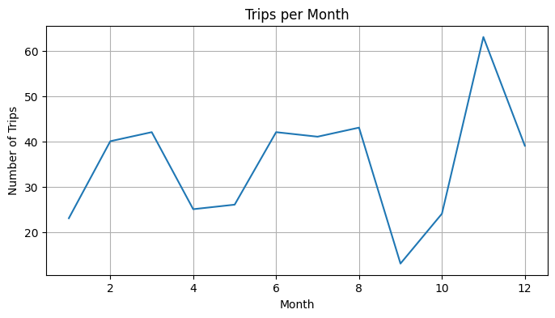

```python
# Trips per month
monthly_trips = df.groupby('month').size()

plt.figure(figsize=(8,4))
plt.plot(monthly_trips.index, monthly_trips.values)
plt.xlabel("Month")
plt.ylabel("Number of Trips")
plt.title("Trips per Month")
plt.grid(True)
plt.show()
```

This code calculates the total miles traveled each month by summing the MILES column grouped by month. It then plots a line chart to show monthly mileage trends, helping to identify peak travel months, seasonal patterns, and overall distance covered over time.

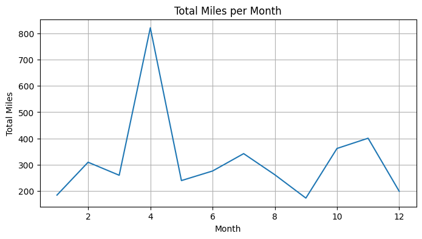

```python
# Total miles per month
monthly_miles = df.groupby('month')['MILES'].sum()

plt.figure(figsize=(8,4))
plt.plot(monthly_miles.index, monthly_miles.values)
plt.xlabel("Month")
plt.ylabel("Total Miles")
plt.title("Total Miles per Month")
plt.grid(True)
plt.show()
```

This code calculates the number of trips for each day of the week using the start_day_of_week feature. It then visualizes the counts with a bar chart, allowing you to see which weekdays have the highest or lowest trip volumes, and identify patterns such as weekday business travel peaks versus weekend travel.

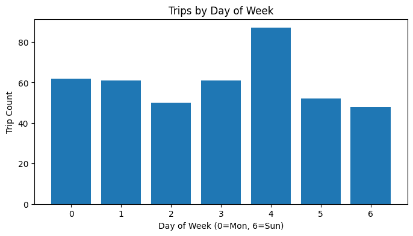

```python
# Trip volume by weekday
weekday_trips = df.groupby('start_day_of_week').size()

plt.figure(figsize=(8,4))
plt.bar(weekday_trips.index, weekday_trips.values)
plt.xlabel("Day of Week (0=Mon, 6=Sun)")
plt.ylabel("Trip Count")
plt.title("Trips by Day of Week")
plt.show()
```

This code calculates the number of trips starting in each hour of the day using the start_hour feature. It then plots a line chart to visualize hourly trip patterns, helping to identify peak travel hours, typical business trip times, and overall daily travel trends.

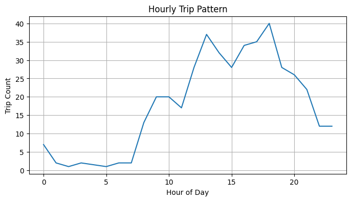

```python
# Hourly Trip patterns
hourly_trips = df.groupby('start_hour').size()

plt.figure(figsize=(8,4))
plt.plot(hourly_trips.index, hourly_trips.values)
plt.xlabel("Hour of Day")
plt.ylabel("Trip Count")
plt.title("Hourly Trip Pattern")
plt.grid(True)
plt.show()
```

**2. Distance & duration**

This code plots a histogram of the MILES column to visualize how trip distances are distributed across the dataset. It helps identify common trip lengths, detect extremely short or long trips, and understand the overall spread of mileage for further analysis or outlier detection.

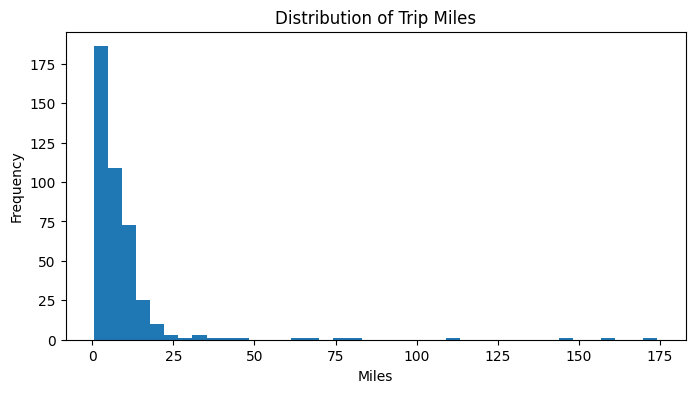

```python
# Distribution of trip miles
plt.figure(figsize=(8,4))
plt.hist(df['MILES'], bins=40)
plt.xlabel("Miles")
plt.ylabel("Frequency")
plt.title("Distribution of Trip Miles")
plt.show()
```

This code plots a histogram of the trip_duration_minutes column, showing how long trips typically last. By visualizing the spread of trip durations, you can identify common travel lengths, detect unusually short or long trips, and assess whether the dataset contains any irregularities that may require cleaning or further investigation.

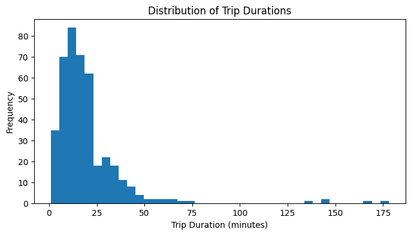

```python
#  Distribution of trip durations
plt.figure(figsize=(8,4))
plt.hist(df['trip_duration_minutes'].dropna(), bins=40)
plt.xlabel("Trip Duration (minutes)")
plt.ylabel("Frequency")
plt.title("Distribution of Trip Durations")
plt.show()
```

This code identifies trips where MILES exceeds 150, marking them as potential outliers. It prints the number of such trips and displays a few examples. This helps detect unusually long trips that may indicate rare travel events, data-entry errors, or trips requiring special attention during analysis.

```python
#  Outlier detection (150+ mile trips)
outliers_miles = df[df['MILES'] > 150]
print("Outlier trips (>150 miles):", len(outliers_miles))
display(outliers_miles.head())
```

```
Outlier trips (>150 miles): 2
```

|  | START_DATE | END_DATE | CATEGORY | START | STOP | MILES | PURPOSE | DURATION_MIN | CITY_PAIR | MPM | ... | start_date | month | year | is_weekend | trip_duration_minutes | miles_per_minute | trip_type | round_trip | city_pair | purpose_group |
| --- | --- | --- | --- | --- | --- | --- | --- | --- | --- | --- | --- | --- | --- | --- | --- | --- | --- | --- | --- | --- | --- |
| 297 | 2016-04-02 19:38:00 | 2016-04-02 22:36:00 | Business | Jacksonville | Ridgeland | 174.2 | Customer Visit | 178.0 | Jacksonville → Ridgeland | 0.978652 | ... | 2016-04-02 | 4 | 2016 | 1 | 178.0 | 0.978652 | long | 0 | jacksonville → ridgeland | customer_visit |
| 299 | 2016-04-03 02:00:00 | 2016-04-03 04:16:00 | Business | Florence | Cary | 159.3 | Meeting | 136.0 | Florence → Cary | 1.171324 | ... | 2016-04-03 | 4 | 2016 | 1 | 136.0 | 1.171324 | long | 0 | florence → cary | meetings |

2 rows × 31 columns

This code creates a scatter plot showing the relationship between trip duration (trip_duration_minutes) and distance (MILES). It helps visualize how mileage scales with time, identify trips that deviate from expected patterns, detect outliers, and understand overall travel behavior in the dataset.

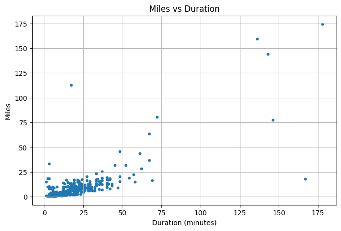

```python
# Relationship: Miles vs Duration
plt.figure(figsize=(8,5))
plt.scatter(df['trip_duration_minutes'], df['MILES'], s=10)
plt.xlabel("Duration (minutes)")
plt.ylabel("Miles")
plt.title("Miles vs Duration")
plt.grid(True)
plt.show()
```

**3. Purpose analysis**

This code counts the number of trips in each purpose_group and displays the results as a horizontal bar chart. This visualization helps identify the most common trip purposes, compare their frequencies, and quickly spot underrepresented categories in the dataset.

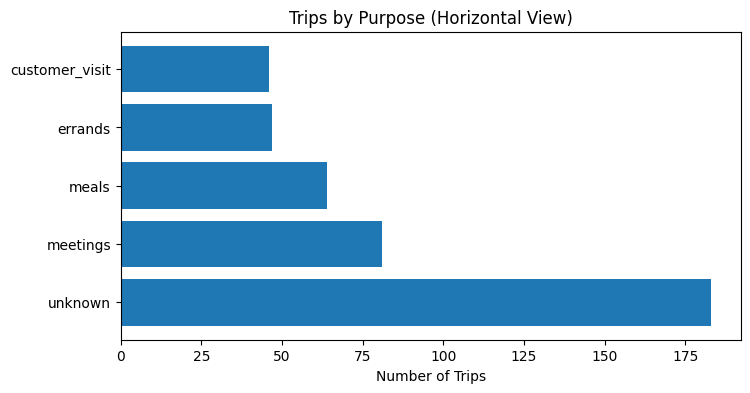

```python
# Count of trips by PURPOSE (Horizontal Bar Chart for uniqueness)
purpose_counts = df['purpose_group'].value_counts()

plt.figure(figsize=(8,4))
plt.barh(purpose_counts.index, purpose_counts.values)
plt.xlabel("Number of Trips")
plt.title("Trips by Purpose (Horizontal View)")
plt.show()
```

This code calculates the total miles traveled for each purpose_group and visualizes the distribution using a pie chart. It provides a clear view of how travel distance is allocated across different purposes, highlighting which trip types contribute most to overall mileage.

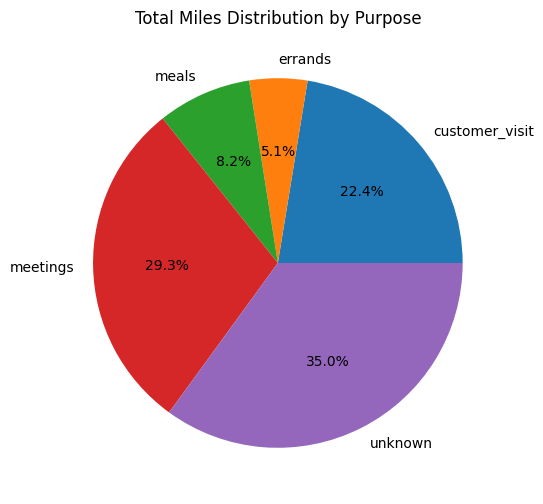

```python
#  Total miles by PURPOSE (Pie Chart — unique visualization)
purpose_miles = df.groupby('purpose_group')['MILES'].sum()

plt.figure(figsize=(6,6))
plt.pie(purpose_miles.values, labels=purpose_miles.index, autopct="%1.1f%%")
plt.title("Total Miles Distribution by Purpose")
plt.show()
```

This code uses a boxplot to show the distribution of MILES for each purpose_group. It highlights the average, spread, and potential outliers of trip distances by purpose, providing insights into which types of trips are typically longer or shorter and the variability within each purpose category.

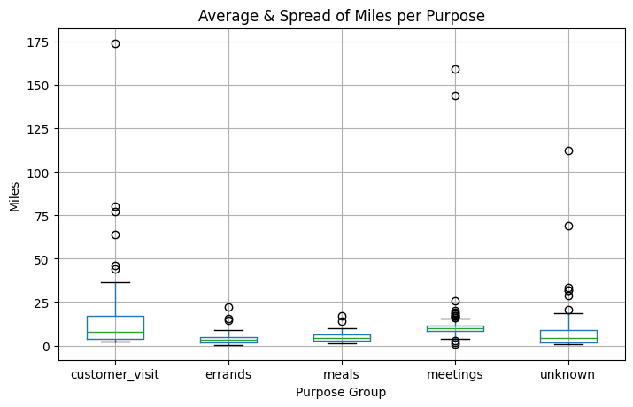

```python
# Average miles per PURPOSE (Boxplot — unique analysis style)
df.boxplot(column='MILES', by='purpose_group', figsize=(8,5))
plt.xlabel("Purpose Group")
plt.ylabel("Miles")
plt.title("Average & Spread of Miles per Purpose")
plt.suptitle("")   # removes default extra title
plt.show()
```

This code tracks how trips for each purpose_group vary across months. By grouping trips by month and purpose_group and plotting line charts for each category, it reveals seasonal trends, peaks, or shifts in travel behavior for different purposes over time, supporting time-based analysis and planning insights.

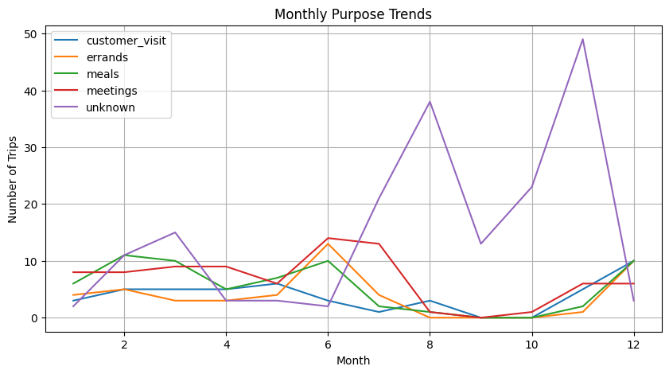

```python
# Purpose trends over time (Line Plot by Month for each purpose)
purpose_monthly = df.groupby(['month', 'purpose_group']).size().unstack(fill_value=0)

plt.figure(figsize=(10,5))
for col in purpose_monthly.columns:
    plt.plot(purpose_monthly.index, purpose_monthly[col], label=col)

plt.xlabel("Month")
plt.ylabel("Number of Trips")
plt.title("Monthly Purpose Trends")
plt.legend()
plt.grid(True)
plt.show()
```

**4. Origin–Destination (START/STOP)**

This code analyzes city-to-city travel patterns. First, it identifies the 15 most common city_pair routes to show frequently traveled paths. Next, it calculates the 15 longest routes based on average miles, highlighting high-distance trips. Finally, it visualizes the top 12 routes using a treemap (squarify) where the size of each block represents average miles per route, providing a clear, hierarchical view of route significance and distance distribution

```
Most Common City Pairs:
```

| city_pair | count |
| --- | --- |
| morrisville → cary | 37 |
| cary → morrisville | 34 |
| cary → cary | 23 |
| cary → durham | 19 |
| durham → cary | 17 |
| unknown location → unknown location | 14 |
| cary → raleigh | 9 |
| westpark place → whitebridge | 8 |
| raleigh → cary | 8 |
| apex → cary | 7 |
| whitebridge → whitebridge | 6 |
| cary → apex | 6 |
| whitebridge → westpark place | 6 |
| edgehill farms → whitebridge | 5 |
| whitebridge → edgehill farms | 5 |

**dtype:** int64

```
Longest City Pair Routes (Avg Miles):
```

| city_pair | MILES |
| --- | --- |
| jacksonville → ridgeland | 174.20 |
| florence → cary | 159.30 |
| ridgeland → florence | 144.00 |
| daytona beach → jacksonville | 80.50 |
| kissimmee → daytona beach | 77.30 |
| r walpindi → unknown location | 65.50 |
| fort pierce → west palm beach | 63.70 |
| berkeley → menlo park | 45.90 |
| santa clara → berkeley | 43.90 |
| menlo park → berkeley | 36.60 |
| wake forest → cary | 31.90 |
| cary → wake forest | 31.70 |
| newark → san francisco | 25.60 |
| chapel hill → cary | 23.30 |
| unknown location → lahore | 20.75 |

**dtype:** float64

```
Downloading squarify-0.4.4-py3-none-any.whl (4.1 kB)
```

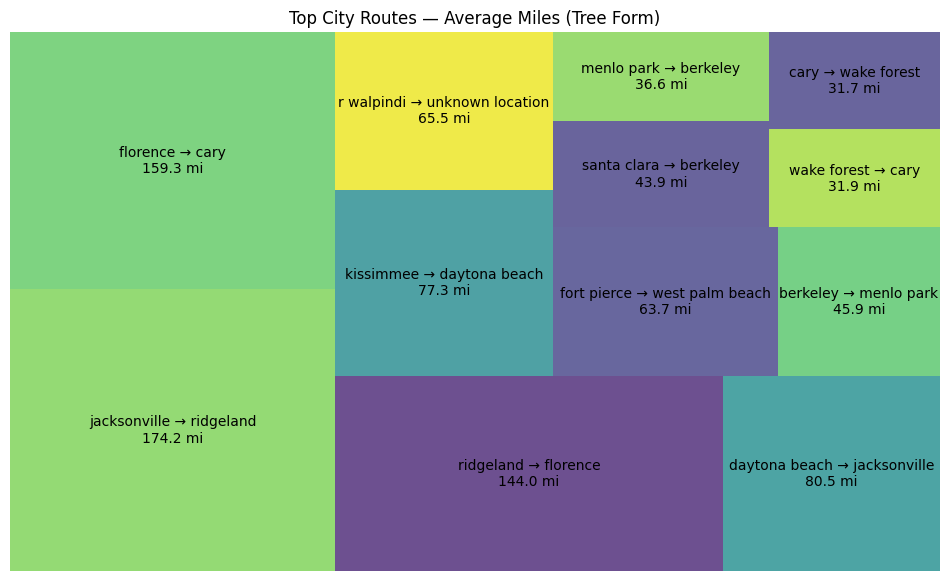

```python
#  Most common city pairs
city_pair_counts = df['city_pair'].value_counts().head(15)
print("Most Common City Pairs:")
display(city_pair_counts)


#Longest city pair routes (based on average miles)
longest_routes = (
    df.groupby('city_pair')['MILES']
      .mean()
      .sort_values(ascending=False)
      .head(15)
)
print("Longest City Pair Routes (Avg Miles):")
display(longest_routes)


#  Average miles per route (Bar Chart)
avg_miles_route = (
    df.groupby('city_pair')['MILES']
      .mean()
      .sort_values(ascending=False)
      .head(12)
)
!pip install squarify

import squarify

# Prepare values
sizes = avg_miles_route.values
labels = [f"{route}\n{miles:.1f} mi" for route, miles in avg_miles_route.items()]

plt.figure(figsize=(12,7))
squarify.plot(
    sizes=sizes,
    label=labels,
    alpha=0.8
)

plt.title("Top City Routes — Average Miles (Tree Form)")
plt.axis('off')
plt.show()
```

**5. Business vs Personal**

This code checks the CATEGORY column to determine if both "Business" and "Personal" trips exist. If only business trips are present, the analysis is skipped. Otherwise, it compares business and personal trips by three metrics: total trip count, total miles traveled, and average trip distance. Each metric is visualized with bar charts to reveal differences in travel frequency, distance covered, and typical trip lengths between business and personal trips.

```
Categories found: ['Business' 'Personal']
Business vs Personal analysis:

Trip Count by Category:
```

| CATEGORY | count |
| --- | --- |
| Business | 407 |
| Personal | 14 |

**dtype:** int64

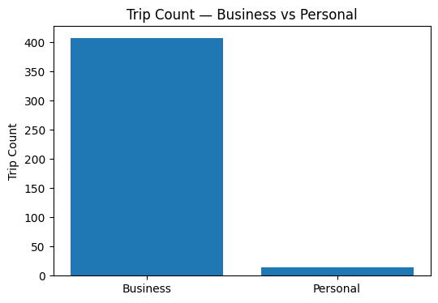

```
Total Miles by Category:
```

| CATEGORY | MILES |
| --- | --- |
| Business | 3774.2 |
| Personal | 49.7 |

**dtype:** float64

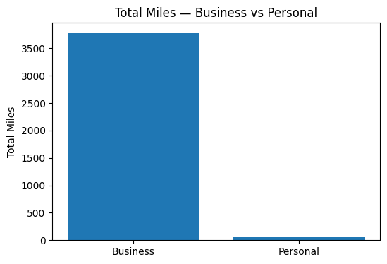

```
Average Miles per Trip:
```

| CATEGORY | MILES |
| --- | --- |
| Business | 9.273219 |
| Personal | 3.550000 |

**dtype:** float64

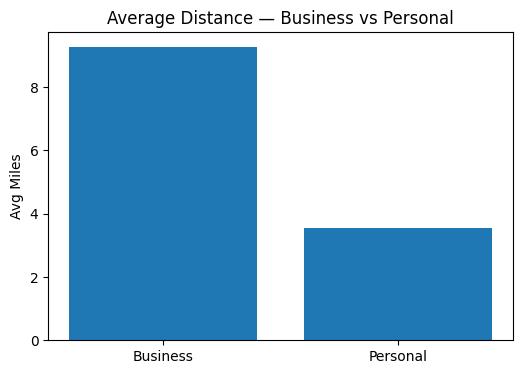

```python
# Check unique categories
cats = df['CATEGORY'].dropna().unique()
print("Categories found:", cats)

# If only Business → skip
if len(cats) == 1 and "Business" in cats:
    print("Only 'Business' category found. Skipping Business vs Personal analysis.")
else:
    print("Business vs Personal analysis:")

    # Trips count
    cat_counts = df['CATEGORY'].value_counts()
    print("\nTrip Count by Category:")
    display(cat_counts)

    plt.figure(figsize=(6,4))
    plt.bar(cat_counts.index, cat_counts.values)
    plt.ylabel("Trip Count")
    plt.title("Trip Count — Business vs Personal")
    plt.show()

    # Total miles by category
    cat_miles = df.groupby('CATEGORY')['MILES'].sum()
    print("\nTotal Miles by Category:")
    display(cat_miles)

    plt.figure(figsize=(6,4))
    plt.bar(cat_miles.index, cat_miles.values)
    plt.ylabel("Total Miles")
    plt.title("Total Miles — Business vs Personal")
    plt.show()

    # Average trip distance
    cat_avg_miles = df.groupby('CATEGORY')['MILES'].mean()
    print("\nAverage Miles per Trip:")
    display(cat_avg_miles)

    plt.figure(figsize=(6,4))
    plt.bar(cat_avg_miles.index, cat_avg_miles.values)
    plt.ylabel("Avg Miles")
    plt.title("Average Distance — Business vs Personal")
    plt.show()
```

**1. Which type of trip consumes the most miles?**

This code answers the question, “Which type of trip consumes the most miles?” by calculating the total miles for each trip_type (Short, Medium, Long). The groupby and sum operation ranks trip types by total mileage, identifying which category contributes most to overall travel distance. The treemap visualization clearly shows the proportion of total miles for each trip type, making it easy to see which trips dominate mileage consumption.

```
trip_type
short     1491.7
medium    1228.3
long      1103.9
Name: MILES, dtype: float64
```

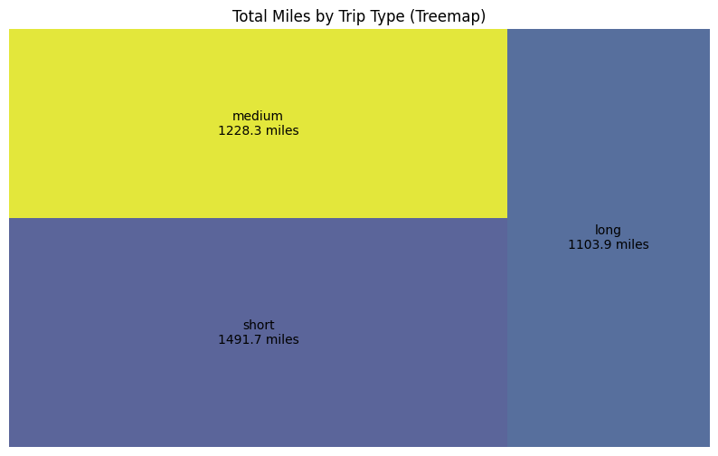

```python
# Total miles per trip type
miles_by_type = df.groupby('trip_type')['MILES'].sum().sort_values(ascending=False)
print(miles_by_type)

# Visualization — Treemap (unique)
import squarify

plt.figure(figsize=(10,6))
squarify.plot(
    sizes=miles_by_type.values,
    label=[f"{t}\n{m:.1f} miles" for t, m in miles_by_type.items()],
    alpha=0.85
)
plt.title("Total Miles by Trip Type (Treemap)")
plt.axis('off')
plt.show()
```

**2. Are meal/entertainment trips unusually short?**

This code investigates whether meal or entertainment trips are unusually short. It separates trips with purpose_group equal to "meals" from all other purposes and compares their durations using a boxplot. The visualization highlights the median, spread, and outliers for both groups, allowing you to see if meal trips tend to be shorter than other trip types and to assess patterns in trip duration for this purpose category.

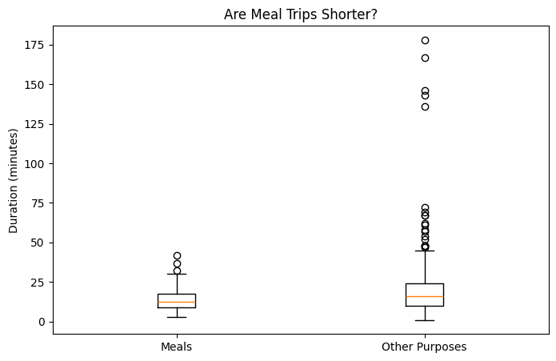

```python
# Compare meal trip durations vs others
meal_durations = df[df['purpose_group'] == 'meals']['trip_duration_minutes']
other_durations = df[df['purpose_group'] != 'meals']['trip_duration_minutes']

plt.figure(figsize=(8,5))
plt.boxplot([meal_durations.dropna(), other_durations.dropna()],
            labels=['Meals', 'Other Purposes'])
plt.ylabel("Duration (minutes)")
plt.title("Are Meal Trips Shorter?")
plt.show()
```

**3. Are meetings clustered in certain hours?**

This code examines whether meeting trips are clustered at specific hours of the day. It filters trips with purpose_group equal to "meetings" and counts how many trips start in each hour (start_hour). The line plot visualizes the frequency of meeting trips by hour, revealing peak times when meetings are most commonly scheduled and highlighting daily patterns in business travel.

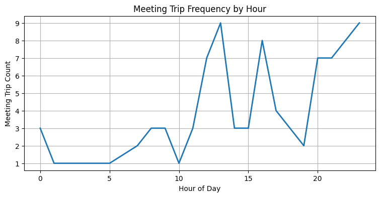

```python
# Meeting trips by hour
meetings_by_hour = (
    df[df['purpose_group'] == 'meetings']
    .groupby('start_hour')
    .size()
)

plt.figure(figsize=(9,4))
plt.plot(meetings_by_hour.index, meetings_by_hour.values, linewidth=2)
plt.xlabel("Hour of Day")
plt.ylabel("Meeting Trip Count")
plt.title("Meeting Trip Frequency by Hour")
plt.grid(True)
plt.show()
```

**4. Does mileage peak in particular months?**

This code analyzes whether trip mileage peaks in certain months. First, it sums MILES per month and displays a bar chart to show total miles traveled each month, highlighting peak travel periods. Then, it calculates the average miles per trip by month and plots a line chart to reveal whether trips themselves tend to be longer in specific months. Together, these visualizations help identify seasonal patterns and months with unusually high travel distances.

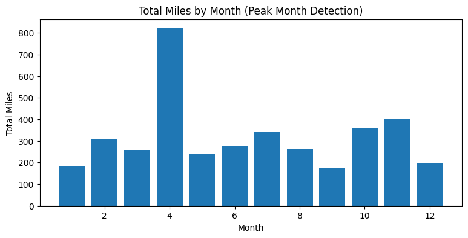

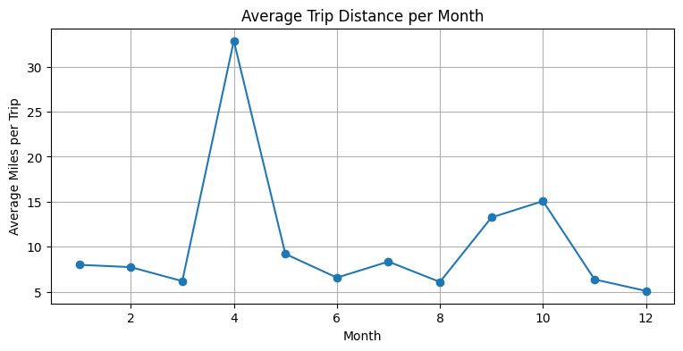

```python
miles_monthly = df.groupby('month')['MILES'].sum()

plt.figure(figsize=(9,4))
plt.bar(miles_monthly.index, miles_monthly.values)
plt.xlabel("Month")
plt.ylabel("Total Miles")
plt.title("Total Miles by Month (Peak Month Detection)")
plt.show()

avg_miles_monthly = df.groupby('month')['MILES'].mean()

plt.figure(figsize=(9,4))
plt.plot(avg_miles_monthly.index, avg_miles_monthly.values, marker='o')
plt.xlabel("Month")
plt.ylabel("Average Miles per Trip")
plt.title("Average Trip Distance per Month")
plt.grid(True)
plt.show()
```

**Final Dataset**

```python
# Create final dataset container
df_final = df.copy()

print("Final dataset successfully stored in df_final")
```

```
Final dataset successfully stored in df_final
```

**Final Processed Dataset Overview**

This code displays the final dataset after completing the full EDA and feature engineering pipeline. It prints the first 20 rows to inspect the processed columns, shows the dataset’s shape to understand the number of rows and columns, and calls info() to verify column types, non-null counts, and overall structure. This step confirms that the dataset is clean, consistent, and ready for further analysis or modeling.

```python
print("\n FINAL DATASET (PROCESSED) \n")
print(df_final.head(20))

print("\n SHAPE ")
print(df_final.shape)

print("\n INFO ")
df_final.info()
```

```
 FINAL DATASET (PROCESSED)

            START_DATE            END_DATE  CATEGORY              START  \
0  2016-01-01 21:11:00 2016-01-01 21:17:00  Business        Fort Pierce
1  2016-01-02 01:25:00 2016-01-02 01:37:00  Business        Fort Pierce
2  2016-01-02 20:25:00 2016-01-02 20:38:00  Business        Fort Pierce
3  2016-01-05 17:31:00 2016-01-05 17:45:00  Business        Fort Pierce
4  2016-01-06 14:42:00 2016-01-06 15:49:00  Business        Fort Pierce
5  2016-01-06 17:15:00 2016-01-06 17:19:00  Business    West Palm Beach
6  2016-01-06 17:30:00 2016-01-06 17:35:00  Business    West Palm Beach
7  2016-01-07 13:27:00 2016-01-07 13:33:00  Business               Cary
8  2016-01-10 08:05:00 2016-01-10 08:25:00  Business               Cary
9  2016-01-10 12:17:00 2016-01-10 12:44:00  Business            Jamaica
10 2016-01-10 15:08:00 2016-01-10 15:51:00  Business           New York
11 2016-01-10 18:18:00 2016-01-10 18:53:00  Business           Elmhurst
```

[output cut: 141 more lines]

Save Final Dataset as CSV

```python
df_final.to_csv("final_trip_dataset.csv", index=False)
print("Final dataset saved as final_trip_dataset.csv")
```

```
Final dataset saved as final_trip_dataset.csv
```

**Conclusion**

This project successfully demonstrates how structured data analysis and feature engineering can transform raw Uber trip data into actionable insights. By cleaning and standardizing key fields such as trip start/end times, city names, mileage, and purpose, we were able to generate meaningful features like trip duration, miles per minute, trip type, city pairs, and purpose groups. Through exploratory data analysis, we uncovered temporal patterns in trips, identified peak travel hours and months, analyzed mileage consumption by trip type, and highlighted frequently traveled routes.

The insights gained provide practical value for ride-sharing operations, helping optimize fleet allocation, identify inefficiencies, and understand customer behavior. For example, short “meal” trips tend to be brief, meetings cluster in certain hours, and certain city pairs contribute disproportionately to total mileage. Overall, this analysis demonstrates the importance of combining data cleaning, feature engineering, and visual analytics to support data-driven decision-making in transportation and ride-sharing services.